# Other cultivated plants

Malcolm Ross

## 1. Introduction

In his study of the uses of plants in central Pacific societies, Thaman (1994) shows that a number of plants are cultivated for purposes other than food production, an observation that equally applies to NW Island Melanesia. There are a number of such plants that have probably been cultivated in the Bismarcks since Proto Oceanic (POc) times. The evidence of longtime cultivation lies in the domesticated varieties of certain plants that only occur under cultivation (sugarcane, *Morinda citrifolia*, *Codiaeum variegatum*, *Cordyline fruticosa*, *Dracaena* angustifolia and *Heliconia indica*) and in the fact that some plants (sugarcane, some bamboo species, kava and *Broussonetia papyrifera*) only reproduce through the planting of cuttings and have no immediate wild relatives. Evidence that they have quite possibly been cultivated continuously since POc times is provided by the POc reconstructions in this chapter.

The plants treated in this chapter are used in a variety of ways. First there are those which are consumed by human beings but do not readily fall under the headings of earlier chapters: sugarcane is sucked to extract the sugar, betelnut is used as a stimulant, kava as a narcotic (§2). Then come plants which provide materials for making things: bamboo, the candlenut for illumination and black dyes, the paper mulberry for making bark cloth, and the Indian mulberry for yellow and red dyes (§3). Fish poisons are treated in §4, turmeric and ginger, which have various uses, in §5, plants with large colourful leaves used for decoration and for magic in §6 and cucurbits in §7. The pumpkin and the cucumber are of course foods, but cucurbits are discussed here, at the end of the volume, because (i) there is a question regarding the dating of the pumpkin’ s introduction(s) into Oceania and (ii) they do not readily belong in any of chapters 9 to 12.

## 2. Plants grown for human consumption

### 2.1. *Saccharum officinarum*, sugarcane, TP suga (Poaceae)

Sugarcane, *Saccharum officinarum* belongs to the family Poaceae, i.e., it is a grass, and is closely related to the wild species *Saccharum spontaneum* (ch.8, §3.4).

Sugarcane is a domesticate, only planted from cuttings, and numerous varieties are found in gardens all over lowland and highland areas of NW Melanesia. Sugarcane prospers especially where the soil is moist and rich (Paijmans 1976: 125-126, Kwa’ioloa & Burt2001: 204, Hviding 2005: 148). The jointed, fibrous stalks contain sucrose, obtained by cutting off a stem and chopping it into convenient lengths which are sucked and chewed as a refreshing snack. When the sugar has been sucked out, the rubbish is spat out.

The POc term *topu ‘sugarcane, *Saccharum officinarum*’ continues PAn *tebuS and is continued throughout Oceanic except in Polynesian, where reflexes attest to PPn *to ‘sugarcane’ rather than expected †*tofu .

| **PAn** |  | *tebuS | ‘sugarcane’ (Blust 1969) |
| --- | --- | --- | --- |
| **POc** |  | *topu | ‘sugarcane, *Saccharum officinarum*’ (Capel11943) |
| Adm | Mussau | *tou* | ‘sugarcane’ |
| Adm | Seimat | *topu* | ‘sugarcane’ |
| Adm | Pak | *tuo* | ‘sugarcane’ |
| NNG | Mengen | *tau* | ‘sugarcane’ |
| NNG | Tuam | *tov* | ‘sugarcane’ |
| NNG | Lukep | *to* | ‘sugarcane’ |
| NNG | Gedaged | *tou* | ‘sugarcane’ |
| NNG | Manam | *tou* | ‘sugarcane’ |
| PT | Wedau | *tom* | ‘sugarcane’ |
| PT | Bwaidoga | *tovu* | ‘sugarcane’ |
| PT | Duau | *tohu* | ‘sugarcane’ |
| PT | Saliba | *tou* | ‘sugarcane’ |
| PT | Motu | *tohu* | ‘sugarcane’ |
| MM | Vitu | *tovu* | ‘sugarcane’ |
| MM | Nakanai | *tovu* | ‘sugarcane’ |
| MM | Tangga | *tuf* | ‘sugarcane’ |
| MM | Siar | *tu* | ‘sugarcane’ |
| MM | Mono-Alu | *tohu* | ‘sugarcane’ |
| MM | Marovo | *tovu* | ‘sugarcane’ |
| TM | Buma | *luro* | ‘coconut’ |
| TM | Nebao | *na-nə* | ‘coconut’ |
| TM | Asuboa | *u-ñio* | ‘coconut’ |
| TM | Tanibili | *no-ñio* | ‘coconut’ |
| SES | Gela | *tovu* | ‘sugarcane’ |
| SES | Kwara’ae | *ufu* | ‘sugarcane’ |
| SES | Arosi | *ohu* | ‘sugarcane’ |
| NCV | Mota | *tou* | ‘sugarcane’ |
| NCV | Mwotlap | *tōw* | ‘sugarcane’ |
| NCV | Ambae | *tovu* | ‘sugarcane’ |
| NCV | Araki | *rovu* | ‘sugarcane’ |
| NCV | Tamambo | *tovu* | ‘sugarcane’ |
| NCV | Nokuku | *tov[u]* | ‘sugarcane’ |
| NCV | Kiai | *tovo* | ‘sugarcane’ |
| NCV | Raga | *toi* | ‘sugarcane’ |
| NCV | Naman | *ni-cəv* | ‘sugarcane’ |
| NCV | Neve’ei | *netev* | ‘sugarcane’ |
| NCV | Larëvat | *n-sev* | ‘sugarcane’ |
| NCV | Uripiv | *na-tiv* | ‘sugarcane’ |
| NCV | Port Sandwich | *na-roev* | ‘sugarcane’ |
| NCV | Paamese | *a-tehi* | ‘sugarcane’ |
| NCV | Lewo | *(puru)tevi* | ‘sugarcane’ |
| NCV | Namakir | *tov* | ‘sugarcane’ |
| SV | North Tanna | *nə-təp* | ‘sugarcane’ |
| SV | Lenakel | *nə-ruw* | ‘sugarcane’ |
| SV | Southwest Tanna | *nə-tukʷ* | ‘sugarcane’ |
| SV | Anejom̃ | *ne-to* | ‘sugarcane’ |
| NCal | Iaai | *(aa)kü* | ‘sugarcane’ |
| NCal | Xârâcùù | *de* | ‘sugarcane’ |
| Mic | Kiribati | *tou* | ‘fruit of the pandanus, chewed like sugarcane’ |
| Mic | Kosraean | *tʌ* | ‘sugarcane’ |
| Mic | Ponapean | *sēw* | ‘sugarcane’ |
| Mic | Woleaian | *wōw* | ‘sugarcane’ |
| Mic | Puluwatese | *wōw* | ‘sugarcane’ |
| Mic | Chuukese | *wōw* | ‘sugarcane’ |
| Fij | Wayan | *tovu* | ‘sugarcane’ |
| Fij | Bauan | *dovu* | ‘sugarcane’ |

cf. also:

| Mic | Marshallese | *taw* | ‘sugarcane’ (probably a loan, according to Bender et al. 2003) |
| --- | --- | --- | --- |

### 2.2. Stimulants and narcotics

One traditional stimulant, the betelnut, *Areca catechu* (§2.2.1 ), and one traditional narcotic, kava, *Piper methysticum* (§2.2.3) are in more or less complementary distribution in Oceania. Betelnut is chewed throughout New Guinea and NW Island Melanesia, whilst kava is consumed in Vanuatu, Fiji, Tonga and Samoa. The one point where the betelnut and kava domains overlapped was Vanikoro, to the east of the main Solomons archipelago (Darrell Tryon, pers. comm.). There were also locations in the small islands of the Admiralties and along the coast of the Madang Province of Papua New Guinea, i.e. in the betelnut domain, where kava was also used, having apparently found its way there from its place of domestication in Vanuatu.

#### 2.2.1. *Areca catechu*, betel palm, betelnut, TP buai, P bilnat, natnat (Arecaceae)

*Areca catechu* is a slender palm which grows up to 30 m. Its crown is smaller relative to its height than that of a coconut, and leaflets are less densely spaced. A many-branched flower cluster develops below the leaf spathe, and the fruit develop from the flowers. The resulting branched cluster of fruit is a familiar sight in markets in lowland Papua New Guinea. The fruit consists of a seed enclosed in a thin green skin and a hard fibrous pericarp, i.e. husk (Figure 13.1, left).

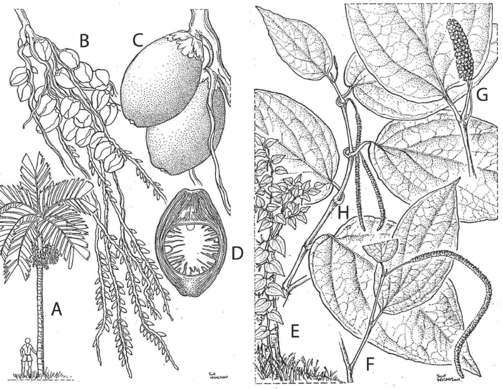

**Figure 13.1:** Left: *Areca catechu*, betelnut: **A**, tree; **B**, portion of inflorescence; **C**, portion of fruit cluster; **D**, fruit: longitudinal section showing fibrous exocarp and inner chewed ‘nut’. Right: *Piper betle*: **E**, plant; **F**, **G**, **H**, flowering shoots of three varieties.

Chewing betelnut as a stimulant is widespread in Papua New Guinea and the Solomon Islands, but not in other parts of the Pacific. Palms are grown in village groves or singly near houses. The seed may be chewed alone, but usually people chew a quid consisting of the seed, lime and a catkin or leaf of *Piper betle* (§2.2.2) (Paijmans 1976: 135).[^1]: Chewing the seed induces salivation, and if lime is present it turns the chewed mass bright red. Some people swallow all but the initial burst of saliva, whilst others spit out the red masticate. Initially, chewing leads to a very short-lived dizziness, folllowed by a sense of renewed wakefulness. In Papua New Guinea and parts of the Solomons chewing betelnut is a social ritual when people meet. Convention requires that the host offer betelnut to visitors (Henderson & Hancock 1988: 146). The husk of the fruit is sometimes used to clean the teeth after chewing, as the quid causes uncleaned teeth to turn dark brown.

Like other palms, the trunk of the betel pallm can be split and the outer wood used for walling or flooring. In the western Solomons, liquid is squeezed from the husk into the eyes of conjunctivitis sufferers.

POc *buaq ‘*Areca catechu*’ is unusual, as both it and POc *puaq ‘fruit’ evidently reflect a single etymon, PMP *buaq, which had many meanings. Blust (ACD) gives the following glosses:

fruit; areca palm and nut; grain; berry; seed; nut; endosperm of a sprouting coconut; kidney; heart; finger; calf of the leg; testicle; various insects; scar tissue; roe; bud; flower; blossom; bear fruit; words, speech, or songs; meaning, contents of discussion; numeral classifier for roundish objects.

He makes the following observations:

1. PMP *buaq formed the head of many head-attribute constructions which functioned as the names of particular fruits (*buaq kuluR ‘breadfruit’, *buaq niuR ‘coconut’, *buaq pahuq ‘mango’, *buaq punti ‘banana’, etc.) … .
2. PMP *buaq almost certainly functioned in addition as a numeral classifier which applied to roundish or fruit like objects … .
3. Most WMP and CMP reflexes support an inference that the meanings ‘fruit’ and ‘areca nut’ were associated with the same morpheme, but the Oc[eanic] evidence suggests that there were two homophonous morphemes. I assume that one morpheme expressed both meanings, but that in POc these meanings become disassociated and connected respectively with oral and nasal grade reflexes of PMP *buaq (POc *puaq ‘fruit’, *mpuaq [our POc *buaq] ‘betel [areca] nut’) … Quite how this disassociation occurred is not clear, as no other similar cases are known. In vol. 1 (ch.2, §2.4), I explained that PMP *band *p merged then split again into POc *b and *p. As a result, one cannot predict whether a PMP etymon with initial *b- will begin with POc *b- or with POc *p–but PMP *buaq is the only etymon known to have both outcomes, in POc *buaq ‘betel [areca] nut’ and POc *puaq ‘fruit’ .

Frantisek Lichtenberk (1998) examines the question of whether POc speakers chewed betelnut, concluding that they did, since a suite of terms associated with betel chewing can be reconstructed. Certainly there are no grounds in the set below for thinking that POc *buaq was diffused across Oceanic languages rather than continued from POc. The easternmost limit of betelnut-chewing is in the Temotu Province of the Solomons, but *buaq is reflected in Southern Vanuatu, where it is applied to palms of other kinds (John Lynch, pers. comm.).

| **PAn** |  | *buaq | ‘fruit’ (ACD; Dempwolff 1938) |
| --- | --- | --- | --- |
| **PMP** |  | *buaq | ‘roundish or fruit-like object, including betelnut, *Areca catechu*’ (see above for the full ACD gloss) |
| **POc** |  | *buaq | ‘betelnut, areca nut, palm, *Areca catechu*’ (Capell1943: *pua(q)) |
| Adm | Mussau | *(ai) bua* | ‘*Areca catechu*’ |
| Adm | Loniu | *bue* | ‘*Areca catechu*’ (Nevermann 1934) |
| Adm | Nyindrou | *puii* | ‘*Areca catechu*’ |
| SJ | Sobei | *pue* | ‘*Areca catechu*’ |
| NNG | Tami | *bu* | ‘*Areca catechu*’ |
| NNG | Kove | *vua* | ‘*Areca catechu*’ |
| NNG | Bariai | *bua* | ‘*Areca catechu*’ |
| NNG | Lukep | *bu* | ‘*Areca catechu*’ |
| NNG | Yabem | *buʔ* | ‘*Areca catechu*’ |
| NNG | Manam | *bua* | ‘*Areca catechu*’ |
| PT | Gabadi | *bua(kau)* | ‘*Areca catechu*’ |
| PT | Motu | *bua(tau)* | ‘*Areca catechu*’ |
| PT | Kilivila | *bua* | ‘*Areca catechu*’ |
| MM | Vitu | *bua* | ‘*Areca catechu*’ |
| MM | Bola | *bua* | ‘*Areca catechu*’ |
| MM | Nakanai | *bua* | ‘*Areca catechu*’ |
| MM | Tolai | *bua* | ‘*Areca catechu*’ |
| MM | Notsi | *bua* | ‘*Areca catechu*’ |
| MM | Tabar | *bua* | ‘*Areca catechu*’ |
| MM | Tangga | *bu* | ‘*Areca catechu*’ |
| MM | Tomoip | *bu* | ‘*Areca catechu*’ |
| MM | Selau | *boko* | ‘*Areca catechu*’ |
| MM | Taiof | *bok* | ‘*Areca catechu*’ |
| MM | Tinputz | *poe* | ‘*Areca catechu*’ |
| MM | Banoni | *buɣava* | ‘*Areca catechu*’ (metathesis of *bu(v)aɣa) |
| MM | Uruava | *bua* | ‘*Areca catechu*’ |
| MM | Torau | *buka* | ‘*Areca catechu*’ (metathesis of *buak) |
| TM | Buma | *buioe* | ‘*Areca catechu*’ |
| TM | Tanema | *boie* | ‘*Areca catechu*’ |
| SES | Gela | *bua* | ‘*Areca catechu*’ |
| SES | Arosi | *bua* | ‘*Areca catechu*’ |
| SES | West Guadalcanal | *bua* | ‘*Areca catechu*’ |
| SES | Talise | *bua* | ‘*Areca catechu*’ |
| SES | Kwaio | *bua* | ‘*Areca catechu*’ |
| SES | ’Are’are | *pua* | ‘*Areca catechu*’ |
| SV | Lenakel | *na-pʷo(k)* | ‘palm sp.’ |
| SV | Kwamera | *na-puei* | ‘coconut’ |

#### 2.2.2. *Piper betle* (syn. *Chavica betle*), betel pepper, TP daka (Piperaceae)

The betel pepper vine, *Piper betle*, is a woody climber with catkins, pendulous spikes of berries in a crowded mass forming a cylindrical syncarp (a composite fruit) (Figure 13.1 , right). It climbs on *Erythrina indica* and Artocarpus incisa. The catkins and/or leaves are chewed with betelnut, *Areca catechu* (§2.2.1), and lime throughout the Bismarck Archipelago and the Solomons (Peekel 1984: 124, Kwa’ioloa & Burt 2001:226, Hviding 2005: 115).

The reconstruction of POc *[pu-]pulu ‘betel pepper, *Piper betle*’ is taken from Lichtenberk’s (1998) discussion of whether POc speakers chewed betelnut. His reconstruction of POc *pulu is based partly on data assembled for the present project, with the addition of Chamorro pu-pulu ‘*Piper betle*’, supporting the: PMP reconstruction, and a Manam reflex. I add Mussau *ulo*.

| **PMP** |  | *pu-pulu | ‘*Piper betle*’ (Frantisek Lichtenberk 1998) |
| --- | --- | --- | --- |
| **POc** |  | *[pu-]pulu | ‘betel pepper, *Piper betle*’ (Frantisek Lichtenberk 1998: *pulu) |
| Adm | Mussau | *ulo* | ‘betel pepper, *Piper betle*’ |
| Adm | Loniu | *pun* | ‘betel pepper, *Piper betle*’ |
| Adm | Bipi | *pun* | ‘betel leaf’ |
| Adm | Bipi | *(pue)pun* | ‘betel pepper’ |
| NNG | Lukep | *ul* | ‘betel pepper, *Piper betle*’ |
| NNG | Takia | *ful* | ‘betel pepper, *Piper betle*’ |
| NNG | Gedaged | *fu* | ‘betel pepper, *Piper betle*’ (expected final-/ missing) |
| NNG | Manam | *ulu(salaga)* | ‘big variety of betel vine’ (salaga ‘be long’; Frantisek Lichtenberk 1998) |
| SES | Bugotu | *vu-vulu* | ‘betel pepper, *Piper betle*’ (Henderson and Hancock 1988) |

| **PMM** |  | *siqa(r,R)(a) | ‘betel pepper, *Piper betle*’ |
| --- | --- | --- | --- |
| MM | East Kara | *sie* | ‘*Piper betle*’ |
| MM | Tabar | *sia* | ‘*Piper betle*’ |
| MM | Lihir | *sie* | ‘*Piper betle*’ |
| MM | Patpatar | *sier* | ‘*Piper betle*’ |
| MM | Tolai | *ier* | ‘*Piper betle*’ |
| MM | Nehan | *hiara* | ‘*Piper betle*’ |
| MM | Petats | *sil* | ‘*Piper betle*’ |
| MM | Teop | *hia(kuru)* | ‘Piper erectum’ |
| MM | Tinputz | *(ta)sian* | ‘*Piper betle*’ |
| MM | Banoni | *siɣana* | ‘betel pepper catkin’ |

cf. also:

| MM | Marovo | *hirata* | ‘*Piper betle*’ |
| --- | --- | --- | --- |

#### 2.2.3. *Piper methysticum*, kava (Piperaceae)

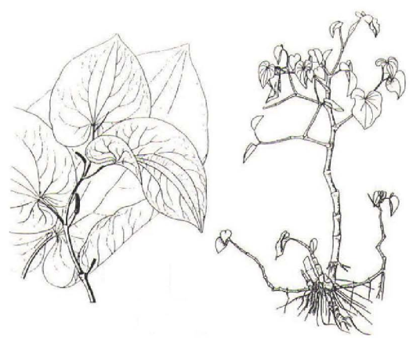

**Figure 13.2:** Leaves, stem and plant habit of kava, *Piper methysticum*

The kava plant, *Piper methysticum*, is a many branching plant with rounded green leaves. The plant is grown, usually near houses, exclusively from cuttings, and a narcotic is made from it in parts of Remote Oceania. Traditionally kava is consumed as a drink. The root is first reduced to small fragments by chewing, grinding or pounding. The fragments are deposited in a bowl, mixed with water and strained through the cloth-like fibre of a coconut spathe (ch.12, §5.3) to give a cloudy grey liquid (Paijmans 1976: 135). In Fiji, Tonga and Samoa the liquid is made from mature roots, is of low strength and plays a part in various ceremonies. In Vanuatu it is made from the roots of green plants and often has a much greater narcotic effect. Initially it causes the blood vessels in the lips and tongue to contract with a certain numbing effect. The drinker then senses some degree of euphoria, followed by a sense of calm well-being and clear thinking and a general relaxation of the muscles.

Kava is also consumed in scattered areas of New Guinea and the Bismarcks. In fact the only Oceanic-speaking areas in this region where it is or was drunk are the small southeastern islands of the Admiralties (Lou, Pam and Baluan; Brunton 1988) and among the Takia ofKarkar Island, where in the 1980s some older men told me that it had been drunk within their lifetimes. The Takia were traditionally in contact with Papuan-speaking villages on the Rai Coast (the north coast of the mainland east of Madang) where Mikloucho-Maclay (Mikloucho-Maclay 1886, 1975) reported that the kava root was chewed by some inhabitants of just a few villages. Bourke (1990) considers that the limited distribution of kava indicates recent introduction, and Miklouho-Maclay noted in 1886 that it had only recently been introduced to the Rai Coast.

Pawley & Green (1973) proposed a POc reconstruction *kawa ‘*Piper methysticum*’. However, the facts that *Piper methysticum* only occurs in domesticated form and that it is not generally consumed in Oceanic-speaking communities in the Bismarcks imply that it was not present there in POc times, and that we should not expect to be able to reconstruct a POc term for it. The origin of kava has attracted a good deal of debate, both botanical and linguistic, over the past 35 years, partly because of its presence at New Guinea locations (Brunton 1988, Lebot 1989, Lebot et al. 1992, T. Crowley 1994, Lynch 2002f).

The best supported hypothesis appears to be that *Piper methysticum* is a domesticated variety of *Piper subbullatum* (syn. *Piper wichmannii*),[^2]: a plant of similar appearance which grows wild in the Solomons (Kwa’ioloa & Burt 2001: 206), and that this domestication took place in northern Vanuatu. The linguistic evidence for this position is presented by Lynch (2002f). He reconstructs a POc term *kawaRi, which he glosses as ‘root with special properties: one or more of *Zingiber zerumbet*, *Piper subbullatum*, fish-poison plants’, i.e. as a generic term for what in the title of his article he calls ‘potent roots’. He points out that none of the apparently directly inherited reflexes of *kawaRi outside Vanuatu, Fiji and Polynesia means ‘kava’ or ‘*Piper methysticum*’. Only reflexes with a form that suggests borrowing have this meaning. The evidence suggests that POc *kawaRi is reconstructable, but only with the ‘potent roots’ meaning. Only in northern Vanuatu and regions settled from it (the rest of Vanuatu, Fiji and Polynesia) do we find directly inherited reflexes denoting ‘kava’ or’ *Piper methysticum*’. The reconstructions and directly inherited reflexes below are from (Lynch 2002f), except where shown.[^3]:

| **POc** |  | *kawaRi | ‘root(s) with special properties: one or more of *Zingiber zerumbet*, *Piper subbullatum*, and various fish-poison plants’ (Lynch 2002f) [^4] |
| --- | --- | --- | --- |
| Adm | Baluan | *kau* | ‘*Piper subbullatum*’ (Ambrose 1991) |
| NNG | Sissano | *(una)kaw* | ‘k.o. ginger’ |
| PT | Muyuw | *ka-kawowa* | ‘Piper sp.’ |
| PT | Gapapaiwa | *kaware* | ‘k.o. ginger’ |
| PT | Tubetube | *kalava* | ‘*Piper subbullatum* (?)’ (metathesis) |
| MM | Maringe | *kʰori* | ‘(use) fish poison’ |
| **PROc** |  | *kawa | ‘kava’; ‘ginger, fish-poison plants’ (presumably) |
| **PNCV** |  | *kea | ‘kava; sour, bitter’ (Lynch 2004a) |
| NCV | Lehali | *n-ɣa* | ‘kava’ |
| NCV | Mota | *ɣea* | ‘kava’ |
| NCV | Mwotlap | *na-ɣa* | ‘kava’ |
| NCV | Vera’a | *ɣie* | ‘kava’; ‘kava; sour, bitter’ |
| NCV | Mwesen | *ɣe* | ‘kava’ |
| NCV | Vera’a | *ɣie* | ‘kava’; ‘kava; sour, bitter’ |
| NCV | Vurës | *ɣe* | ‘kava; sour, bitter’ |
| NCV | Araki | *hae* | ‘kava; sour, bitter’ |
| NCV | Lewo | *(wi)kawa* | ‘brackish water’ (*wi* ‘water’) |
| **PCP** |  | *kawa | ‘kava, Piper sp., fish-poison plants; sour, bitter’; ‘*Zingiber* spp.’ (probably also) |
| Fij | Bauan | *(wā)gawa-gawa* | ‘*Piper betle*’ |
| Fij | Nadrogā | *kawa* | ‘fish-poison tree, Euphorbia sp. (?)’ |
| Fij | Lautoka | *kawa* | ‘fish-poison vine, *Derris* sp.’ |
| Fij | (many dialects) | *kawa* | ‘k.o. round fish-trap with mouth on top, made from *Derris* vines’ |
| **PPn** |  | *kawa | ‘kava; sour, bitter’ |
| Pn | Tongan | *kava* | ‘kava’ |
| Pn | West Futunan | *kava* | ‘kava’ |
| Pn | Samoan | *ʔava* | ‘kava’ |
| Pn | Samoan | *ʔa-ʔava* | ‘pungent, acrid’ |
| Pn | Hawaiian | *ʔava* | ‘kava; sour, bitter’ |
| Pn | Rarotongan | *kava* | ‘kava; sour’ |
| Pn | Māori | *kawa* | ‘sour, bitter; perform certain kinds of ceremony’ |
| Pn | Māori | *kawa-kawa* | ‘*Macropiper excelsum*’ |

The denotations of PCP *kawa as ‘Piper sp.’, ‘*Zingiber* spp.’ and ‘fish-poison plant’ are continued as compounds in PPn:

| **PNPn** |  | *kawa-kawa qatua | ‘a shrub or vine, Piper sp.’ |
| --- | --- | --- | --- |
| Pn | East Futunan | *kava-kava atua* | ‘a climbing vine, *Piper vaupelii*’ |
| Pn | Marquesan | *kava-kava atua* | ‘*Piper latifolium*, Piper tristachyon’ |
| Pn | Rarotongan | *kava-kava atua* | ‘a shrub, *Piper latifolium*’ |

| **PPn** |  | *kawa-sasa | ‘a creeper used to poison fish’ |
| --- | --- | --- | --- |
| Pn | Tongan | *kava-haha* | ‘*Derris trifoliata*, used as a fish poison’ |
| Pn | East Futunan | *kava-sasa* | ‘a vine’ |
| Pn | Samoan | *ʔava-sa* | ‘shrub sp., *Tephrosia purpurea* sp., used to poison fish’ |

| **PPn** |  | *kawa-susu | ‘shrub sp., *Tephrosia* sp., used to poison fish’ |
| --- | --- | --- | --- |
| Pn | Niuean | *kau-huhu* | ‘a plant used to stupefy fish’ |
| Pn | East Uvean | *kava-huhu* | ‘shrub sp., *Tephrosia piscatoria*’ |
| Pn | East Futunan | *kava-susu* | ‘shrub sp., the leaves of which are used to poison fish’ |
| Pn | Nukuoro | *gava-usu* | ‘*Barringtonia asiatica*, used to poison fish’ |

| **PNPn** |  | *kawa-pui | ‘a plant, *Zingiber* sp.’ |
| --- | --- | --- | --- |
| Pn | Tikopia | *kava-pui* | ‘plant of the ginger family’ |
| Pn | East Uvean | *kava-pui* | ‘*Zingiber* sp.; white ginger, *Hedychium coronarium*’[^5] |
| Pn | Anutan | *kava-pui* | ‘Alpinia sp.’ |
| Pn | Samoan | *ʔava-pui* | ‘a herb, *Zingiber zerumbet*’ |
| Pn | Hawaiian | *ʔawa-puhi* | ‘wild ginger, *Zingiber zerumbet*’ |
| Pn | Tahitian | *ava-puhi* | ‘an odiferous plant’ |

## 3. Plants which provide materials for making things

### 3.1. *Bambusa*, *Schizostachyum* and_Nastus_ spp., bamboo, TP mambu, Bbambu (Poaceae)

Three genera of bamboos are represented in NW Island Melanesia: *Bambusa*, *Schizostachyum* and *Nastus*. They are treated together here, since only one of the reconstructable terms can be related to a particular species. A number of species are often cultivated.

Three species of *Bambusa*, all thick-walled, are reported from the region. The most common in the Bismarcks and the largest in the Solomons is *Bambusa vulgaris*, with a culm (walled stem) about 5-10 m high and 10-15cm in diameter and a short internode distance around 30-50 cm. However, *Bambusa vulgaris* was introduced after European contact (Rhys Gardner, pers. comm.) and was not among the denotata of the POc terms below. *B. blumeana* is very similar and apparently important only in Malaita. *B. forbesii*, reported from the Bismarcks, is smaller, with a culm 2-4 m high and 1-4cm diameter, and has broad leaves (Peekel 1984: 55-56, Henderson & Hancock 1988: 203-205).

*Bambusa* bamboos are used in housing construction for beams and rafters, as well as to make containers for lime and water and tongs for lifting the hot stones of a stone oven (Henderson & Hancock 1988: 204–205). At Marovo they are used to make large traditional tuna-fishing rods and a whole stem serves as a ‘ladder’ to climb sago palms in order to cut its fronds (Hviding 2005: 117).

Two species of the thin-walled genus *Schizostachyum* are reported from the region. No comparative account is available, but the two appear similar. *Schizostachyum lima*, found in the Bismarcks, has a culm about 4–8 m high and 4–10cm in diameter, with internode lengths of 50-80 cm (Peekel 1984: 55). *S. tessellatum*, found in the Solomons, is described as tall and very thin, growing wild in many habitats in clumps 10 m tall. It is the only bamboo amongst the three genera that is observed to flower regularly

*Schizostachyum* species are a source of very straight, lightweight poles with many purposes: as battens from which to hang sago leaf thatch, as yam poles, as small fishing rods and as spears. Pieces of *Schizostachyum* are used to make traditional panpipes and coconut scrapers. They are also used as fencing material (Henderson & Hancock 1988:202-203, Hviding 2005: 107, Kwa’ioloa & Burt 2001: 202).

Three species of the thin-walled genus *Nastus* are reported from the region. One is *Nastus productus*, a small, often drooping bamboo. A second is *Nastus obtusus*, a very slender bamboo which is almost always cultivated and attains heights of over 20 m with stem diameters of 8-11cm and internode lengths of 50 em to a metre. A third *Nastus* species is not given a scientific name,[^6]: but sources describe it as pliant and behaving as a tree or ground creeper. It has very short internode lengths and small, narrow leaves (Peekel 1984: 55, Henderson & Hancock 1988: 177, Kwa’ioloa & Burt 2001: 200-201).

The first two *Nastus* species, and especially *Nastus obtusus*, have similar uses to those of *Schizostachyum*, but the third *Nastus* species is considered by the Kwara’ae to be useless (Henderson & Hancock 1988: 176, 199-201, Kwa’ioloa & Burt 2001:200–202, Hviding 2005: 112).

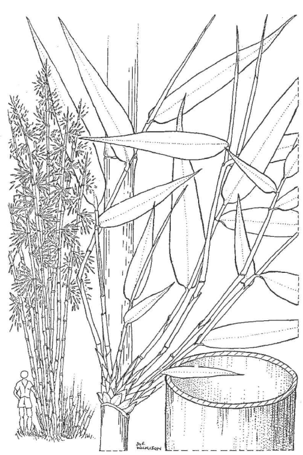

**Figure 13.3:** *Nastus obtusus*

The term reconstructed as *qauR ‘bamboo spp.’ below was probably the generic term for bamboos of the three genera mentioned above, as it still is in some modern languages. In Tolai, for example, we find the following:

| MM | Tolai | *kaur* | ‘*Bambusa vulgaris*’ |
| --- | --- | --- | --- |
| MM | Tolai | *kaur lubaŋ* | ‘*Bambusa vulgaris*, larger variety’ |
| MM | Tolai | *kaur goragoro* | ‘*Schizostachyum lima*’ |
| MM | Tolai | *kaur laur* | ‘thin-walled bamboo species’ |

PAn *qauR ‘bamboo’ is attested in Fom1osan languages, PMP *qauR ‘bamboo’ in languages across Indonesia (Blust, ACD ), and a number of Oceanic languages have reflexes indicating POc *qauR. However, there are als:o a number of languages that reflect initial *k- rather than *q-, and I show below the POc segments seemingly reflected by the consonant(s) of each form in order to illuminate the discussion here. In those Remote Oceanic languages which reflect POc *k- and *q- differently from one another the form indeed reflects initial *q-. However, in Meso-Melanesian languages which reflect POc *k- and *q- differently and in Temotu languages the form reflects *k-, not *q-.

On the basis of Meso-Melanesian reflexes POc *kauR ‘bamboo’ was reconstructed as in vol.1 (ch.4, §6.2). However, non-Oceanic and Remote Oceanic data support *qauR.[^7]:

Among languages which retain a reflex of the final consonant, Mussau and Petats reflect *d or *dr, rather than *R, and Nakanai reflects *s or *c.[^8]: The Bilibil, Gedaged and Sio forms reflect final *-R where the final consonant is normally lost.

Blust (1984) reconstructed POc *kaudru[^9]: ‘bamboo sp.’ to account for the Mussau, Petats and Selau forms.[^10]: However, it does not account for the other irregularities below, and its putative reflexes are here treated as (albeit irregular) reflexes of POc *qauR. Instead, the simplest linguistic explanation of these irregularities is that the forms reflect borrowings among neighbouring Oceanic languages. Indeed, it is possible that some of the forms with regular reflexes also result from borrowings, but happen to have regular reflexes of the consonants. However, it is not easy to see why such borrowings might have occurred, unless much of Near Oceania lacked useful bamboo species, and new species were imported by Oceanic speakers. Hviding (2005: 107, 112, 117) hints at this when he writes that old people say that *Bambusa vulgaris*, *B. blumeana*, *Nastus obtusus* and a *Schizostachyum* species were all long ago introduced to Marovo from elsewhere. It is just possible that some of these borrowings were associated with the introduction of *Bambusa vulgaris* after contact with Europeans.

| **PAn** |  | *qauR | ‘bamboo sp.’ (ACD) |
| --- | --- | --- | --- |
| **PMP** |  | *qauR | ‘type of large bamboo’ (ACD) |
| **POc** |  | *qauR | ‘bamboo spp.’ |
| Adm | Mussau | *kauru* | ‘large bamboo from which combs are made’ (*k~q *d~dr) |
| NNG | Mangap | *kau-kau* | ‘bamboo (big)’ (*k~q) |
| NNG | Bilibil | *aur* | ‘bamboo’ (*k~q *r~R) |
| NNG | Gedaged | *auɬ* | ‘bamboo, tall with thick walls’ (*k~q *r~R) |
| NNG | Sio | *kaul(a)* | ‘bamboo’ (*k~q *r~R) |
| NNG | Lukep | *kau-kau* | ‘bamboo’ (*k~q) |
| NNG | Atui | *kaur* | ‘bamboo’ (*k~q *r<sub>R</sub>d~dr) |
| NNG | Akolet | *e-kaur* | ‘bamboo’ (*k~q *r<sub>R</sub>d~dr) |
| MM | Bali | *kaura* | ‘bamboo’ (*k *r~R) |
| MM | Nakanai | *kauru* | ‘large bamboo’ (*k *s~c) |
| MM | Ramoaaina | *kauru* | ‘bamboo’ (*k~q *r~R) |
| MM | Tolai | *kaur* | ‘bamboo, generic’ (*k~q *r~R) |
| MM | Patpatar | *kor* | ‘bamboo, generic’ (*k~q *r~R) |
| MM | Petats | *kahur* | ‘bamboo’ (*k *d~dr) |
| MM | Selau | *kawur* | ‘bamboo’ (*k *r<sub>R</sub>d~dr) |
| MM | Mono-Alu | *aulu* | ‘bamboo sp.’ (*k *r<sub>R</sub>l) |
| SES | Gela | *ɣau* | ‘a bamboo, bamboo knife’ (*k~q) |
| SES | Bugotu | *ɣau* | ‘bamboo; bamboo sliver used as a knife’ (*k~q) |
| SES | West Guadalcanal | *ɣau-ɣau* | ‘bamboo’ (*k~q) |
| SES | Lau | *ʔau* | ‘bamboo’ (*k~q) |
| SES | Kwara’ae | *kaʔo* | ‘bamboo (generic)’ (*k~q) |
| SES | Kwaio | *ʔau* | ‘bamboo (generic)’ (*k~q) |
| SES | Sa’a | *äu* | ‘bamboo’ (*k~q) |
| SES | Arosi | *ʔau* | ‘a bamboo’ (*k~q) |
| NCV | Mota | *au* | ‘the bamboo, generic’ (*k~q) |
| NCV | Southeast Ambrym | *eou* | ‘bamboo’ (*k~q) |
| NCV | Paamese | *eau* | ‘bamboo’ (*k~q) |
| NCV | Lewo | *(pla)yu* | ‘bamboo, as knife’ (*k~q) |
| NCV | Port Sandwich | *n-au* | ‘arrow’ (*k~q) |
| NCV | Namakir | *ʔo* | ‘bamboo’ (*q) |
| NCV | Nguna | *na-au* | ‘wild cane, reed; flute, mouth organ’ (*k~q) |
| SV | Sye | *n-au* | ‘bamboo’ (*q) |
| SV | Ura | *n-au* | ‘spear’ (*q) |
| SV | North Tanna | *n-ao* | ‘bamboo’ (*q) |
| SV | Whitesands | *n-au* | ‘bamboo’ (*q) |
| SV | Lenakel | *n-au* | ‘bamboo’ (*q) |
| SV | Kwamera | *n-au* | ‘bamboo’ (*q) |
| SV | Anejom̃ | *n-au* | ‘bamboo’ (*q) |
| NCal | Nêlêmwa | *ŋ-ga* | ‘bamboo’ (*q) |
| NCal | Nyelâyu | *ŋ-gao* | ‘bamboo’ (*q) |
| NCal | Jawe | *ŋ-go* | ‘bamboo’ (*q) |
| NCal | Pije | *(du)ko* | ‘bamboo’ (*q) |

Reflexes of POc *bʷau ‘bamboo’ are largely complementary to those of *qauR above, with overlaps on the mainland coast of the Vitiaz Strait and in New Caledonia. The Manam and Kaiep reflexes provide a weak indication that *bʷau may have denoted bamboo as a construction material.

| **POc** |  | *bʷau | ‘bamboo’ |
| --- | --- | --- | --- |
| SJ | Ormu | *bau* | ‘bow’ |
| NNG | Tami | *bʷai* | ‘bamboo’ |
| NNG | Malasanga | *boa* | ‘bamboo’ (irregular loss of *u) |
| NNG | Bing | *buau* | ‘bamboo’ |
| NNG | Manam | *buau-buau* | ‘(house) wall’ |
| NNG | Kaiep | *ba-boi* | ‘(house) wall’ |
| PT | Molima | *bau-bau* | ‘bamboo tube, smoking pipe made therefrom’ (A. Chowning, pers. comm.) |
| PT | Dobu | *bau-bau* | ‘bamboo’ |
| PT | Duau | *bau-bau* | ‘bamboo’ |
| PT | Wedau | *bau-bau* | ‘bamboo’ |
| PT | Tawala | *bau-bau* | ‘bamboo’ |
| PT | Tubetube | *bau-bau* | ‘bamboo’ |
| PT | Motu | *bau* | ‘bamboo’ |
| Mic | Marshallese | *bʷae* | ‘bamboo’ |
| Mic | Woleaian | *pʷāɨ* | ‘bamboo’ |
| Mic | Chuukese | *pʷāw* | ‘bamboo’ |
| Mic | Puluwatese | *pʷāy* | ‘bamboo’ |
| NCal | Nyelâyu | *gao* | ‘bamboo’ |

Five more reconstructions are listed below: POc *bitu(ŋ) ‘bamboo sp., probably *Schizostachyum glaucifolium*’, POc *botu(ŋ), POc *kopu, POc *bʷele, POc *bue ‘(made of) bamboo’. Except for the first and last, the glosses of the supporting data do little to help elucidate their denotata, some of which were presumably taxa made up of one or more of the species discussed above. The gloss of Nakanai hele ‘small cultivated bamboo used for thatching rods’ suggests that it denotes a *Schizostachyum* species, but this is insufficient information on which to base a gloss of POc *bʷele.

The two reconstructions below are better supported by non-Oceanic than by Oceanic reflexes. Since *Bambusa* vulgaris is a recent import, the Fijian and Polynesian glosses indicate that PCP *hitu probably denoted *Schizostachyum* glaucifolium. This may also be true of the POc reflex, but this is uncertain.

| **PMP** |  | *bituŋ, *pituŋ | ‘bamboo sp.’ (ACD) |
| --- | --- | --- | --- |
| **POc** |  | *bitu(ŋ) | ‘bamboo sp.’ (ACD) |
| **PCP** |  | *bitu | ‘bamboo sp., probably *Schizostachyum glaucifolium*’ (ACD) |
| Fij | Wayan | *bitu* | ‘generic for two bamboo species, *Schizostachyum glaucifolium* and *Bambusa vulgaris*’ |
| Fij | Bauan | *bitu* | ‘bamboo, *Bambusa* sp. or *Schizostachyum glaucifolium*’ |
| Pn | Tongan | *pitu* | ‘bamboo, *Bambusa vulgaris*, variety with yellow stems’ |

| **PAn** |  | *betuŋ | ‘bamboo of very large diameter, probably *Dendrocalamus* sp.’ (ACD) |
| --- | --- | --- | --- |
| **POc** |  | *botu(ŋ) | ‘large bamboo, presumably *Bambusa* sp.’ (ACD: *potuŋ) |
| Adm | Lou | *pot* | ‘large thick bamboo variety’ |

| **POc** |  | *kopu | ‘bamboo sp.’ |
| --- | --- | --- | --- |
| Adm | Drehet | *ɔp* | ‘bamboo sp.’ |
| Adm | Nyindrou | *op* | ‘bamboo sp.’ |
| MM | Tinputz | *kop* | ‘bamboo sp.’ |
| MM | Teop | *kopu* | ‘bamboo sp.’ |

The only non-WOe evidence for POc *bʷele ‘bamboo’ is from Lonwolwol (NCV), where *bʷele-bo* consists of *bʷele-* ‘hollow vessel’ and *bo*, apparently reflecting PNCV *bue ‘made of bamboo’ (see below). A possible inference is that *bʷele denoted bamboo as a household utensil, e.g. a container for water.

| **POc** |  | *bʷele | ‘bamboo sp.’ |
| --- | --- | --- | --- |
| NNG | Mapos Buang | *a-pɛl* | ‘bamboo sp.’ |
| NNG | Patep | *pɛel* | ‘bamboo sp.’ |
| MM | Bulu | *bele* | ‘bamboo sp.’ |
| MM | Nakanai | *bele* | ‘small cultivated bamboo used for thatching rods’ (Goodenough 1997) |
| MM | Tiang | *bele* | ‘bamboo sp.’ |
| NCV | Lonwolwol | *bʷele(bo)* | ‘bamboo’ (*bʷele-* ‘hollow vessel’; *-bo* <POc *bue ‘(made of) bamboo’) |

Hus (Adm) *ʙu* ‘bamboo’ corresponds regularly with the NCV items below, implying that it and PNCV *bue both reflect a POc *bue ‘(made of) bamboo’.

| **POc** |  | *bue | ‘(made of) bamboo’ |
| --- | --- | --- | --- |
| Adm | Hus | *ʙu* | ‘bamboo’ (Nevermann 1934) |
| **PNCV** |  | *bue | ‘(made of) bamboo’ (Clark 1996) |
| NCV | Mota | *pue* | ‘bamboo water-carrier’ |
| NCV | Raga | *bua* | ‘bamboo (generic); knife’ |
| NCV | Nokuku | *pue* | ‘water-pot’ |
| NCV | Kiai | *pue* | ‘bamboo’ |
| NCV | Araki | *(vi)pue* | ‘bamboo tree’ |
| NCV | Tamambo | *(vu)bue* | ‘bamboo tree’ |
| NCV | Uripiv | *na-ʙu* | ‘bamboo’ |
| NCV | Port Sandwich | *na-mbu* | ‘bamboo; bamboo water container; bamboo knife’ |
| NCV | Port Sandwich | *mbʷe(var)* | ‘hard bamboo’ (*na-var* ‘stone’) |
| NCV | Labo | *(na-na)mbuo* | ‘bamboo’ |
| NCV | Lonwolwol | *(bʷele)bo* | ‘bamboo’ (*bʷele-* ’hollow vessel, empty shell of) |
| NCV | Lewo | *(pila)pʷe* | ‘bamboo (used for walls of house); length of thatch woven on bamboo’ |

### 3.2. *Aleurites moluccana* (syn._Aleurites triloba_), candlenut, P kandoltri, Bkandeltri (Euphorbiaceae)

*Aleurites moluccana* is a tree which grows to between 10 and 35 m in height, depending on its location. Its young leaves and inflorescence are dusted with grey to rust-brown scurf, and the mature fruit is chestnut brown, 3-7cm in diameter. It has little pulp and a thick rind that encloses one or two very large seeds, the candlenuts. There appears to be considerable intra-species variation across its range, from India to eastern Polynesia, as well as a striking variety of uses. The seeds of some varieties are toxic, but others can be eaten without a problem. Even toxic seeds can often be eaten in small quantities, and the toxicity is reduced by roasting (Henty 1982, Walter & Sam 2002: 87).

In Vanuatu *Aleurites moluccana* is not cultivated, as planted seeds do not germinate well, but people protect new seedlings (Walter & Sam 2002: 88). In Fiji the tree occurs close to villages but not in the wild, implying that it is planted.

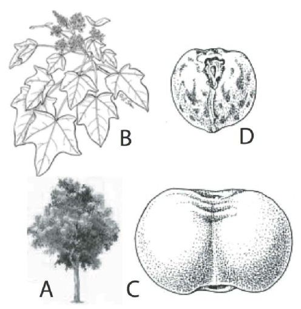

**Figure 13.4:** *Aleurites moluccana*: **A**, tree; **B**, leaves and inflorescence; **C**, whole fruit; **D**, kernel (candlenut).

The candlenut owes its name to the fact that in earlier times the nuts were threaded onto the midrib of a coconut palm leaf and lit, burning slowly one after another and giving a feeble light. The smoke given off is also a good insect repellant (Sperlich 1997). Charred seeds are used in New Ireland to make a sooty paint for blackening the face in mourning (Peekel 1984: 313) and by Ponapeans for making a black or brown dye. The oil extracted from them is also used as a paint base in New Britain (Powell 1976) and to polish wood in Fiji, where an extract of the seed is also used to scent the oil (Gardner & Pawley 2006). The products of *Aleurites moluccana* have numerous medicinal uses (Walter & Sam 2002: 89).

POc *tuRi-tuRi ‘*Aleurites moluccana*’ is reconstructed below. It is quite widely supported, but it is by no means certain that its denotatum was *Aleurites moluccana*. Blust (ACD) reconstructs PEMP *tuRi-tuRi ‘*Aleurites moluccana*’ on the basis of Biak kuker ‘tree with edible nut’ and Central Pacific reflexes. However, Geraghty (2004: 72) believes that PPn *tuitui ‘*Aleurites moluccana*’ was identical with *tuitui ‘strung together’, reflecting the fact that candlenuts are strung together for use as torches or sources of dye. He does not discuss Blust’s reconstruction, but if Geraghty is right, the Biak, Motu and Roro terms must be dismissed as chance resemblances (none has the specific gloss *Aleurites moluccana*).

| **PEMP** |  | *tuRi-tuRi | ‘candlenut tree, *Aleurites moluccana*’ (?) (ACD) |
| --- | --- | --- | --- |
| **POc** |  | *tuRi-tuRi | ‘candlenut tree, *Aleurites moluccana*’ (?) |
| PT | Motu | *turi-turi* | ‘*Cordia subcordata*’ |
| PT | Roro | *curi-curi* | ‘tree sp., with wood used for making drums’ |
| **PCP** |  | *tui-tui | ‘candlenut tree, *Aleurites moluccana*’ |
| Fij | Bauan | *tui-tui* | ‘candlenut, *Aleurites moluccana*’ |
| Pn | Tongan | *tui-tui* | ‘candlenut, *Aleurites moluccana*’ |
| Pn | Niuean | *tui-tui* | ‘candlenut, *Aleurites moluccana*’ |
| Pn | East Uvean | *tui-tui* | ‘candlenut, *Aleurites moluccana*’ |
| Pn | East Futunan | *tui-tui* | ‘candlenut, *Aleurites moluccana*’ |
| Pn | West Futunan | *tu-tui* | ‘candlenut, *Aleurites moluccana*’ |
| Pn | Emae | *tui-tui* | ‘candlenut, *Aleurites moluccana*’ |
| Pn | Tahitian | *tu-tui* | ‘candlenut, *Aleurites moluccana*’ |
| Pn | Tuamotuan | *tui-tui* | ‘candlenut, *Aleurites moluccana*’ |
| Pn | Hawaiian | *ku-kui* | ‘candlenut, *Aleurites moluccana*’ |
| Pn | Rarotongan | *tui-tui* | ‘candlenut, *Aleurites moluccana*’ |

### 3.3. *Broussonetia papyrifera*, paper mulberry, TP burua (Moraceae)

*Broussonetia papyrifera* is native to Japan and Taiwan and is an ancient introduction into the rest of the Pacific. A shrub or small tree 3-5, and sometimes up to 12, metres high, it is fertile in its native range, but the plants found throughout the Pacific are all male clones, transported and planted as rootstock. It is thus subject to deliberate propagation by human agency (Whistler & Elevitch 2006a ).

As Osmond & Ross noted in vol.1 (ch.4, §5.1), Kooijman (1972:446–453) believes from descriptions of manufacture and an examination of museum pieces that bark cloth in New Guinea was made from *Ficus* and Artocarpus species rather than from *Broussonetia papyrifera*, from which bark cloth is made in other parts of the Pacific, e.g. Fiji (Gardner & Pawley 2006). However, the glosses of the items listed below suggest fairly strongly that speakers of Oceanic languages in widely separated New Guinea locations were using *Broussonetia papyrifera* to make bark cloth at European contact.

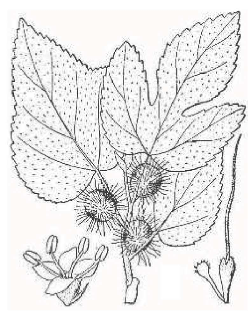

**Figure 13.5:** *Broussonetia papyrifera*, paper mulberry

POc *malo probably denoted *Broussonetia papyrifera*, the tree which throughout much of the Pacific provides the bast from which barkcloth is made. If this is so, then *Broussonetia papyrifera* must have been introduced into the Pacific islands by early Oceanic speakers. Matthews (1996), however, notes its absence from the Philippines and Borneo, and thinks it possible that it did not arrive in Polynesia with the earliest colonisers. POc *malo also denoted the cloth and the male genital covering made from it, and it is just possible that these were its primary meanings. It is also possible that some of the reflexes below reflect early Pacific Pidgin malo or maro ‘loincloth’. PMP *mal(u,aw) apparently denoted a species of tree which provided bast for clothmaking, but it is unclear which species this was, as it is reconstructed on the basis of POc *malo and Kaili (WMP, Sulawesi: Parigi dialect) *malo* ‘old term for *Trema amboinensis*, the tree whose bast is most commonly used for barkcloth in Sulawesi’ (Adriani & Kruijt 1901: 140, note 5, cited by R. Kennedy 1934: 242).

| **PMP** |  | *mal(u,aw) | ‘tree whose bast is used for barkcloth’[^11] |
| --- | --- | --- | --- |
| **POc** |  | *malo | ‘paper mulberry, *Broussonetia papyrifera*; barkcloth, loincloth’ (Milke 1968) |
| NNG | Kove | *malo* | ‘male genital covering’ (A. Chowning, pers. comm.) |
| NNG | Gedaged | *mal* | ‘tree, bark used for G-strings and blankets; loincloth made from this’ |
| NNG | Takia | *malu* | ‘tree sp., loin cloth made from pounded bark’ |
| NNG | Manam | *malo* | ‘barkcloth belt from dodoli tree, given to a boy at first initiation’ (Böhm 1983: 81) |
| MM | Patpatar | *māl* | ‘cloth, clothing’ |
| MM | Tolai | *mal* | ‘*Broussonetia papyrifera*; native cloth made from bark of this tree’ |
| MM | Teop | *maro* | ‘cloth, clothing’ |
| SES | Arosi | *maro* | ‘*Broussonetia papyrifera*; beaten cloth of the maro tree’ |
| NCV | Raga | *malo* | ‘men’s loincloth’ |
| Fij | Bauan | *malo* | ‘*Broussonetia papyrifera*; hence the native cloth made from it and the former native male dress, passed between the thighs and fastened with a girdle’ |
| **PPn** |  | *malo | ‘barkcloth loin garment’ (POLLEX) |
| Pn | Emae | *maro* | ‘barkcloth’ |
| Pn | Samoan | *malo* | ‘loincloth’ |
| Pn | Hawaiian | *malo* | ‘loin garment’ |

| **POc** |  | *(m,mʷ)ase | ‘wild mulberry, paper mulberry, *Broussonetia papyrifera*’ (Ross 1996d) |
| --- | --- | --- | --- |
| NNG | Mapos Buang | *ñɛ̃s* | ‘*Broussonetia papyrifera*’ |
| MM | Tolai | *mae* | ‘*Broussonetia papyrifera*’ |
| Fij | Wayan | *masi* | ‘*Broussonetia papyrifera*’ |
| Fij | Rotuman | *mɔsi* | ‘tree sp. used to make bark cloth’ |

### 3.4. *Morinda citrifolia*, Indian mulberry, yellow wood, P ialotri, Byelotri, noni (Rubiaceae)

A small tree, 5-6 min height, and occasionally more, up to 15m, *Morinda citrifolia* (Figure 13.6, left) grows throughout Oceania behind the beach and in dry soils exposed to the sun. Barrau (1962: 188) comments on the large shiny elliptical leaves about 20cm in length and 10cm broad. Peekel (1984: 539) recognises two varieties, one with green, yellow, white or variegated leaves, the other (var. bracteata) with enlarged calyx lobes. The small white flowers grow on an oval or cone-shaped structure, the syncarpium, which later swells to become the syncarp, ‘a heavy, pungent smelling-sometimes repulsive-succulent fruit’ (Henderson & Hancock 1988: 52). The fruits of wild varieties are spherical or elongated syncarps of 3-6cm and are soft and straw yellow at maturity, with numerous protuberances (French 1986:272 describes them as ‘warty looking lumps’). Cultivated forms have paler, larger fruit with no protuberances, but are rarely found within village areas because of the strong smell when their fruit fall and rot (Walter & Sam 2002: 204-205).

*Morinda citrifolia* is a tree with many uses in Oceanic speaking societies. Wild young trees are well known as a source of dyes, red and yellow, extracted by boiling the root-bark (Floyd 1954, Gowers 1976: 99). In Marovo the dyes are applied to cocount-frond baskets, in Vanuatu to vegetable fibres used in items of apparel. S. Foale (2001) describes it as an all-purpose medicine on Lihir, and Walter & Sam (2002: 206–207) refer to research indicating that the Indian mulberry contains immuno-stimulant substances. This would explain its numerous medicinal uses. In Marovo, Manus and Tonga young leaves softened over the fire are applied to infected wounds and boils to draw out pus (O’Collins & Lamothe 1989, Hviding 2005: 133, Walter & Sam 2002: 207). In Vanuatu the raw fruit is crunched and eaten to treat an enlarged spleen. However, the plant is also cultivated and the fruit of the cultivated variety eaten, raw or cooked, on small islands scattered across Papua New Guinea, on the Temotu islands of the Solomons and in the Banks and Torres Islands of Vanuatu. Elsewhere the fruit of the wild variety is a famine food (Walter & Sam 2002: 205-207). In parts of Papua New Guinea and the Solomons the young leaves, which are a rich source of carotene, are cooked as a vegetable or consumed for medicinal reasons (Henderson & Hancock 1988:54, French 1986: 272).

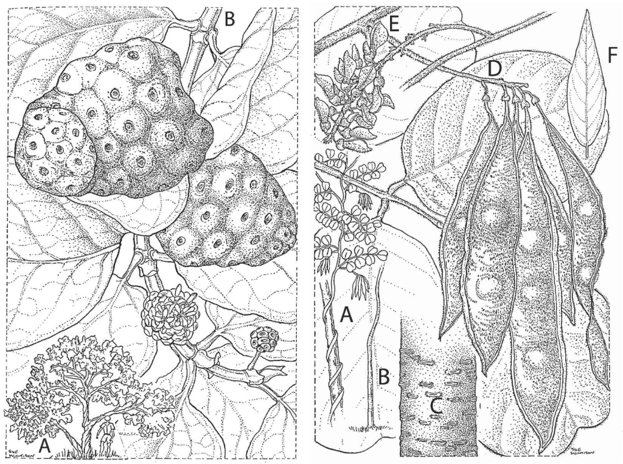

**Figure 13.6:** **Left** *Morinda citrifolia*, Indian mUtlberry: **A**, mature tree; **B**, shoot bearing leaves, fruit and flowers. **Right** *Derris* species: **A**, climbing plant; **B**, base of mature vine; **C**, woody vine stem; **D**, vine with leaves and pods; **E**, stem with inflorescence; **F**, immature leaf.

There were apparently two POc labels for *Morinda citrifolia*, *fiofiu and *kurat. If Verheijen (1990: 86) has correctly identified the referent of Bima (CMP) nonu as *Morinda citrifolia* (he marks it with a question mark), then *fiofiu is reconstructable for PCEMP and was inherited into POc. If Tagalog, Bisayan, Tausug nino *Morinda citrifolia* (Madulid 2001a: 527) are also cognate with POc *fiofiu, then PMP *fiefiu is reconstructable. Milke reconstructed this etymon as POc *fiofium with final *-m, but the only reflexes with this segment are Gedaged nonom and Takia nom. Both languages lose POc final *- VC, and it is more likely that -m in both languages irregularly reflects medial POc *-fi-, with reduplication in Gedaged.

Geraghty (1993) speculates that *fiofiu (his *fiofium) was the name of the plant and *kurat the name of the dye produced from it. In Geraghty (2004: 91) he finds support for this speculation in evidence provided by Mahdi (1994: 192-193). Papuan languages of the North Halmahera family show forms such as Temate guraci ‘turmeric’, Tidore guraci ‘gold’, *guraci* ‘yellow’. These are the source of loans in Malaya-Polynesian languages of the South Halmahera family such as Buli *guraci ‘gold’. Geraghty suggests that such a form could also have been borrowed into languages of the New Guinea region and thence into early Oceanic. This proposal seems very plausible and leads to a speculation of my own. As Geraghty points out, the formal correspondence of the Halmahe:ra and Oceanic forms is perfect. In the light of this, it is possible that POc *kurat reflects a PEMP form *gurati meaning ‘yellow dye’.

The distributions of POc *ñoñu and *kurat are complementary: *kurat is reflected solidly through Melanesia from New Ireland (Lihir, Tangga) through NW Solomonic (Nehan, Roviana), SE Solomonic, North/Central and Southern Vanuatu, New Caledonia and Fiji, while *ñoñu occurs in the Admiralties, North New Guinea, Papuan Tip, Micronesian and Polynesian. These distributions suggest that POc *ñoñu was in some sense the default term for *Morinda citrifolia* and that it was then replaced by *kurat in a solid Melanesian block from New Ireland to New Caledonia and Fiji. However, the reflexes of *kurat are generally regular, suggesting that replacement took place very early in the history of Oceanic.[^12]:

| **POc** |  | *ñoñu | ‘*Morinda citrifolia*’ (Blust 1978b; Milke 1965: *nonum) |
| --- | --- | --- | --- |
| Adm | Seimat | *naun* | ‘*Morinda citrifolia*’ (*-o- > Seimat *-au-*) (Sorensen 1950) |
| Adm | Leipon | *ñoñ* | ‘*Morinda citrifolia*’ |
| Adm | Bipi | *ñoy* | ‘*Morinda citrifolia*’ |
| NNG | Gitua | *nono* | ‘*Morinda citrifolia*’ |
| NNG | Gedaged | *no-nom* | ‘*Morinda citrifolia*’ |
| NNG | Takia | *nom* | ‘*Morinda citrifolia*’ |
| NNG | Manam | *noŋ* | ‘tree sp.’ |
| NNG | Wogeo | *ñoñ* | ‘*Morinda citrifolia*’ |
| PT | Bwaidoga | *nono* | ‘*Morinda citrifolia*’ |
| PT | Motu | *nonu* | ‘*Morinda citrifolia*’ |
| Mic | Kiribati | *non* | ‘*Morinda citrifolia*’ |
| Mic | Marshallese | *nen* | ‘*Morinda citrifolia*’ |
| Mic | Puluwatese | *nēn* | ‘*Morinda citrifolia*’ |
| Mic | Woleaian | *lēli* | ‘*Morinda citrifolia*’ |
| Pn | Tongan | *nonu* | ‘*Morinda citrifolia*’ |
| Pn | Tikopia | *nonu* | ‘*Morinda citrifolia*’ |

| **POc** |  | *kurat | ‘the dye produced from *Morinda citrifolia*’ (Geraghty 2004) |
| --- | --- | --- | --- |
| MM | Lihir | *ulet* | ‘Morinda sp.’ |
| MM | Tangga | *urat* | ‘*Morinda citrifolia*’ |
| MM | Nehan | *rata* | ‘*Morinda citrifolia*’ |
| MM | Mono-Alu | *urati* | ‘*Morinda citrifolia*’ (W. McClatchey, pers. comm.) |
| MM | Varisi | *ku-kure* | ‘*Morinda citrifolia*’ (W. McClatchey, pers. comm.) |
| MM | Roviana | *ɣurata* | ‘*Morinda citrifolia*’ |
| **PEOc** |  | *kurat | ‘M orinda citrifolia’ |
| SES | Longgu | *ʔura* | ‘*Morinda citrifolia*’ |
| SES | Santa Ana | *ɣura* | ‘*Morinda citrifolia*’ |
| NCV | Mwotlap | *wʋy* | ‘*Morinda citrifolia*’ |
| NCV | Mota | *wura* | ‘*Morinda citrifolia*’ |
| NCV | Ambae | *hure* | ‘*Morinda citrifolia*’ |
| NCV | Araki | *hura* | ‘*Morinda citrifolia*’ |
| NCV | Raga | *ɣuresi* | ‘*Morinda citrifolia*’ (Walsh 2004) [^13] |
| NCV | Uripiv | *na-ur* | ‘*Morinda citrifolia*’ |
| NCV | Paamese | *o-ulo* | ‘*Morinda citrifolia*’ |
| NCV | Lewo | *(pur)kula* | ‘*Morinda citrifolia*’ |
| NCV | Nguna | *na-kura* | ‘tree sp.’ |
| NCV | South Efate | *na-kur* | ‘*Morinda citrifolia*’ |
| **PSV** |  | *na-ɣura(t,c) | ‘*Morinda citrifolia*’ (Lynch 2001c) |
| SV | Sye | *noɣrat* | ‘*Morinda citrifolia*’ |
| SV | Lenakel | *nauias* | ‘*Morinda citrifolia*’ |
| SV | Kwamera | *noueis* | ‘*Morinda citrifolia*’ |
| SV | Anejom̃ | *na-uras* | ‘*Morinda citrifolia*’ |
| NCal | Nyelâyu | *yelac* | ‘*Morinda citrifolia*’ |
| NCal | Iaai | *hulak* | ‘*Morinda citrifolia*’ |
| NCal | Dehu | *xelek* | ‘*Morinda citrifolia*’ |
| Fij | Wayan | *kura* | ‘*Morinda citrifolia*’ |
| Fij | Rotuman | *ʔurɔ* | ‘*Morinda citrifolia*’ |

## 4. Fish poisons

One method of catching fish was to put a toxic plant substance into an area of water surrounded by rocks or reef so that fish were stunned or killed and could then simply be collected by hand. As well as the plants described bellow, the seeds of the tree *Barringtonia asiatica* (ch.5, §5.2) were also used for this purpose.

### 4.1. *Derris* spp., derris root, fish poison plant, TP *vut* (Fabaceae)

The use of climbing shrubs of the genus *Derris* to stun fish for an easy catch is known from the Bismarcks to Fiji (see vol.1, ch.8, §7). However, of fifteen *Derris* species that Verdcourt (1979: 314–331) identifies in Papua New Guinea, only three are said to be used for fishing: *Derris elliptica*, *Derris* elegans (syn. *D. rufula*, *Dillenia salomonensis* and perhaps *Derris heterophylla*) and *Derris* malaccensis. We can evidently add a fourth, as Peekel mentions the use of *Derris trifoliata* (syn. *D. uliginosa*) to stun fish, a claim confirmed by Hviding (2005: 105).

In its wild form *Derris* elliptica is a climbing shrub up to 10m high which grows in coastal locations (Figure 13.6, right). Cultivated plants are mostly low and tangled, and produce thick fleshy roots which are scraped or crushed, then stirred into shallow water to benumb fish so that they can be easily caught.

Chewing derris root and then swallowing copious amounts of water was the traditional means of suicide in NW Island Melanesia.

*Derris trifoliata* is a smaller species but has a thicker stem, larger leaves and a weaker fish- stunning effect than *Derris elliptica* (Peekel 1984: 243). Hviding (2005: 105) reports that in Marovo *Derris trifoliata* is indigenous, and *Derris elliptica* has been introduced from New Guinea.

It seems likely that POc *tupa referred to *Derris* creepers in general, or at least to those used in fishing, and perhaps also to *Derris elliptica* in particular, as this was the source of the strongest poison. Also reconstructable are

- POc *puna(t) ‘vine used for fish poison, probably *Derris elliptica*’
- PWOc *m(ʷ)ali ‘*Derris* sp.’
- PROc *vuba ‘k.o. vine, probably *Derris elliptica*’

but I am unable to determine how they differed in meaning from each other or from *tupa.

| **PMP** |  | *tuba | ‘*Derris* fish poison’ (Dempwolff 1938) |
| --- | --- | --- | --- |
| **POc** |  | *tupa | ‘climbing shrubs, *Derris* spp.’ (Capell 1943) |
| Adm | Seimat | *tu[hi]* | ‘*Derris* sp.’ (Sorensen 1950) |
| NNG | Aria | *tuva* | ‘derris root’ |
| NNG | Kove | *tuva* | ‘derris root’ |
| PT | Molima | *tuva* | ‘derris root’ |
| PT | Kilivila | *tuva* | ‘poisonous root used for fishing’ |
| PT | Motu | *tuha* | ‘derris root’ |
| MM | Vitu | *tuva* | ‘derris root’ |
| MM | Tigak | *tua* | ‘derris root’ |
| MM | Teop | *suva* | ‘derris root’ |
| MM | Mono-Alu | *tuha* | ‘*Derris heterophylla*’ (W. McClatchey, pers. comm.) |
| MM | Marovo | *tuva* | ‘*Pongamia pinnata*’ |
| SES | Gela | *tuva* | ‘derris root’ |
| SES | Sa’a | *uha, uhe* | ‘derris root’ |
| NCV | Mota | *tua* | ‘a creeping plant used to poison fish’ |
| NCV | Uripiv | *na-tuv* | ‘fish poison vine’ |
| **PSV** |  | *(i)tuv | ‘*Derris* sp. usually trifoliata’ (Lynch 2004a) |
| SV | Sye | *(nos)(i)tup* | ‘*Derris* sp. usually trifoliata’ (*nos* ‘vine’) |
| NCal | Nyelâyu | *(ñale)jep* | ‘derris root’ |
| NCal | Xârâcùù | *(kʷa)dɨ* | ‘derris root’ |
| Mic | Woleaian | *sūpe* | ‘fish poison (root)’ (*-p-* for †*-f-*) |
| Fij | Wayan | *tuva* | ‘generic for *Derris* spp.’ |
| Fij | Rotuman | *fuha* | ‘*Derris* spp., used to stun fish’ |

PMP *bunat is reconstructed on the basis of the Oceanic data here and Botolan Sambal bunat ‘*Derris elliptica*’.

| **PMP** |  | *bunat | ‘*Derris* elliptica’ |
| --- | --- | --- | --- |
| **POc** |  | *puna(t) | ‘vine used for fish poison, probably *Derris* elliptica’ |
| Adm | Lou | *pun* | ‘vine used for fish poison’ |
| PT | Sudest | *vun* | ‘poison fish with derris’ |
| MM | Tolai | *vun* | ‘*Derris elliptica*, root with which fish are poisoned; to kill or benumb fish with poison of this name’ |
| MM | Nduke | *buna* | ‘*Derris heterophylla*, a poison-leaf vine, crushed and thrown into rock-holes to stun reef fish’ |
| MM | Roviana | *buna* | ‘littoral vine (macerated and thrown into rock pools, it stupefies fish)’ |
| MM | Marovo | *buna* | ‘climber with poisonous leaves, fish poison’ |
| SV | Lenakel | *no-un* | ‘fish poison’ |

PWOc *(m,mʷ)ali is reconstructed on the basis of North New Guinea and Meso-Melanesian languages:

| **PWOc** |  | *(m,mʷ)ali | ‘*Derris* sp.’ |
| --- | --- | --- | --- |
| NNG | Gitua | *(waro)mali(ŋ)* | ‘*Derris* root’ |
| MM | Nalik | *mal-mal* | ‘*Derris* root’ |
| MM | East Kara | *mal* |  |
| MM | Sursurunga | *mel* | ‘a vine used to poison fish or humans’ |
| MM | Marovo | *moli* | ‘a coastal creeping vine’ |

Bender et al. (2003) offer two Proto Micronesian reconstructions with the gloss ‘fish poison’ or ‘*Derris* sp.’. One is PMic *(t,T)upa, continuing POc *tupa and reflected only in Woleaian *sūpe* ‘fish poison (root)’. Since *sūpe* has *-p-* for †*-f* and PMic *(t,T)upa is reconstructed for expected †*tufa, the reconstruction is suspect. The other PMic reconstruction is *upa ‘derris vine’, which is well supported in Micronesian languages and appears to have cognates in Southern Vanuatu, permitting reconstruction of PROc *vuba.

| **PROc** |  | *vuba | ‘k.o. vine, probably *Derris elliptica*’ |
| --- | --- | --- | --- |
| **PSV** |  | *na-vup | ‘k.o. vine’ (Lynch 2001c: 236) |
| SV | Sye | *na-vup* | ‘k.o. vine, probably *Derris elliptica*’ |
| SV | Anejom̃ | *no-hop(ɣev)* | ‘k.o. vine, probably *Derris elliptica*’ |
| **PMic** |  | *upa | ‘*Derris* vine’ (Bender et al. 2003) |
| Mic | Kosraean | *op* | ‘plant used as fish poison’ |
| Mic | Marshallese | *wep* | ‘a tree, *Barringtonia asiatica*, seeds used for fish poison’ |
| Mic | Ponapean | *ūp* | ‘*Derris elliptica*’ |
| Mic | Ponapean | *ūpa-wp* | ‘to poison fish’ |
| Mic | Chuukese | *wɨ̄p, wɨpe(n)* | ‘*Derris elliptica*’ |

## 5. Multi-purpose roots

Turmeric and ginger are both cultivated for their roots, which have a variety of uses. Among these are magical applications, shared with the first three plants in §6. Like the candlenut (§3 .2) and Indian mulberry (§3.4) turmeric also produces a dye.

### 5.1. *Curcuma longa* (syn. *Curcuma domestica*), turmeric (Zingiberaceae)

The turmeric: plant, *Curcuma longa*, is much smaller than Alpinia species, being only 50-120cm tall, but it is treated by at least speakers of Marovo and Kwara’ae as belonging to the same taxon as Alpinia (Kwa’ioloa & Burt 2001:193-194, Hviding 2005: 131).[^14]: It has long green leaves and pale yellow flowers. The rhizome is lumpy and an intense yellow (Peekel 1984: 109).

Although it grows readily in the wild in locations where there is light, the Marovo and Kwara’ae sources also report that it is often cultivated. The rhizome provides spice. It is also a source of yellow dye, but the colour fades easily (Floyd 1954, Peekel 1984: 109). At Marovo the aromatic leaves are used for parcelling fish for the stone oven.

Turmeric also has ritual significance. At Marovo it is planted to keep evil spirits away from gardens, and in both Marovo and Kwara’ae the roots are chewed and spat out of the door or window of the house to fend off evil spirits (Hviding 2005: 131). The Kwara’ae also chew it both with betelnut and alone, the latter both as a snack and medicinally.

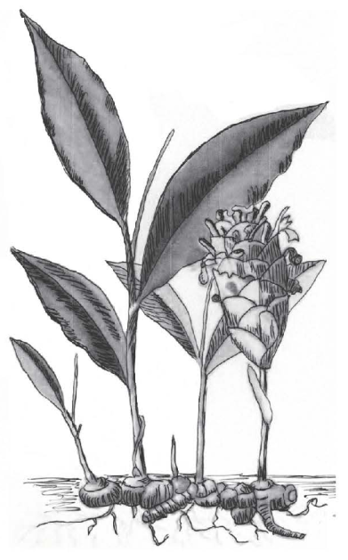

**Figure 13.7:** *Curcuma longa*

There are two reconstructions, POc *yaŋo and PEOc *re(ŋ,ŋʷ)a. There is some evidence in the glosses of reflexes that the latter meant yellow material, including prepared turmeric and perhaps the yolk of an egg.

| **POc** |  | *yaŋo | ‘turmeric, *Curcuma longa*’ (Milke 1968) |
| --- | --- | --- | --- |
| NNG | Mangap | *(n)aŋgo-ŋgo(ŋana)* | ‘a plant, ginger type, yellow when crushed’ (*-ŋana* ‘nominaliser’) |
| NNG | Adzera | *yaŋa(n)* | ‘ginger’ |
| MM | East Kara | *ioŋ* | ‘turmeric’ |
| MM | Patpatar | *iaŋ* | ‘turmeric’ |
| MM | Kubokota | *aŋo* | ‘plant similar to ginger, of various colours (white and yellow); it has various medicinal and magical uses in healing and cursing’ |
| MM | Nduke | *aŋo* | ‘turmeric’ |
| MM | Roviana | *aŋo* | ‘turmeric’ |
| NCV | Mota | *aŋo* | ‘turmeric’ |
| Mic | Ponapean | *ɔ̄ŋ* | ‘turmeric’ |
| Mic | Mokilese | *ɔŋ* | ‘turmeric’ |
| Mic | Woleaian | *yāŋa* | ‘ginger’ |
| Fij | Bauan | *ðaŋo(laya)* | ‘wilid ginger, *Zingiber zerumbet*’ |
| Fij | Bauan | *ðaŋo* | ‘turmeric’ |
| Pn | Tongan | *aŋo* | ‘turmeric’ |
| Pn | Tongan | *aŋo-aŋo* | ‘shampoo ginger, *Zingiber zerumbet*’ |
| Pn | Samoan | *aŋo* | ‘turmeric’ |

The root above was the source of the POc term for ‘yellow’, *yaŋo-yaŋo:

| **POc** |  | *yaŋo-yaŋo | ‘yellow’ (Grace 1969) |
| --- | --- | --- | --- |
| NNG | Kove | *eaŋ-eaŋo* | ‘yellow’ |
| NNG | Tami | *yaŋo-yaŋo* | ‘yellow’ |
| NNG | Kairiru | *yaŋ-yaŋ* | ‘yellow’ |
| NNG | Manam | *aŋo-aŋo* | ‘yellow’ |
| PT | Molima | *yawo-yawo(na)* | ‘yellow’ |
| MM | Nakanai | *ial-alo* | ‘yellow’ |
| SES | Gela | *aŋo-aŋo* | ‘yellow’ |
| NCV | Mota | *aŋo-aŋo* | ‘yellow’ |
| Mic | Woleaian | *yaŋo-yaŋo* | ‘yellow colour of ginger’ |
| Fij | Wayan | *aŋo-aŋo* | ‘yellow’ |
| Fij | Bauan | *ðaŋo-ðaŋo(a)* | ‘reddish or orange like the turmeric plant’ |

| **PEOc** |  | *[re]reŋʷa | ‘yellow material, prepared turmeric(?)’ (Biggs 1965: *reŋa) |
| --- | --- | --- | --- |
| SES | Sa’a | *reŋa* | ‘decorate with black, white and red designs; beautiful’ |
| NCV | Loh | *eŋ* | ‘turmeric’ |
| NCV | Mota | *re-reŋa* | ‘yolk of an egg; yellow colour’ |
| Mic | Kiribati | *reŋa* | ‘*Curcuma tonga*’[^15] |
| Fij | Wayan | *re-reŋʷa* | ‘*Curcuma longa*, turmeric’ |
| Fij | Bauan | *re-reŋa* | ‘turmeric’ |
| Pn | Tongan | *eŋa* | ‘turmeric’ |
| Pn | Rennellese | *ŋeŋa* | ‘prepared turmeric’ |
| Pn | Samoan | *leŋa* | ‘yellow dye from turmeric’ (Whistler 2000: 177) |
| Pn | Tokelauan | *leŋa* | ‘yolk of egg, turmeric’ |
| Pn | Tahitian | *reʔa* | ‘ginger, turmeric’ |
| Pn | Hawaiian | *lena* | ‘yellow’ |
| Pn | Māori | *reŋa-reŋa* | ‘a large: herb with curcuma-like leaves and short rhizome, Arthropodium cirratum’ (R. Gardner, pers. comm.) |

### 5.2. *Zingiber* spp., ginger, TP *kawawar* (Zingiberaceae)

*Zingiber officinale* (common ginger), 50-120cm tall, cultivated and wild, serves as a spice plant, medicine and magic (Peekel 1984:100). It appears to have arrived in Near Oceania a long time ago (R.M. Bourke, pers. comm.), but does not seem to have been carried into (at least parts of) Remote Oceania until European contact, where the only species of ginger was *Zingiber zerumbet* (‘wild ginger’, ‘shampoo ginger’, ‘pinecone ginger’), a woody shrub, 80-120 cm high with long narrow green leaves and magnificent red flowers which resemble a pinecone in shape. It is widely cultivated, with numerous cultivars.

If it is true that *Zingiber officinale* did not find its way into Remote Oceania with Oceanic speakers, then one must ask whether it had in fact arrived in NW Island Melanesia by POc times. This is a matter which seems to require further research.

In Marovo wild ginger was associated with magic and sorcery. The leaves of particular varieties were important in calling on ancestor spirits, and the roots were chewed for magical purposes. In earlier times, one was planted at each comer of a garden to protect it against destructive magic. The roots of some varieties are chewed for their healing properties. Because of these associations, ginger is rarely used in ordinary cooking (Hviding 2005: 130).[^16]: Peekel (1984: 101) in any case reports that the rhizome of *Zingiber zerumbet* is less tasty than those of other *Zingiber* species.

Two POc terms are reconstructed below. The gloss of the first, *laqia, remains a little doubtful because of the difficulty in dating the arrival of *Zingiber officinale* in NW Island Melanesia. POc *para(k) evidently referred to Zingiberaceae species but just how large a taxon it denoted is currently unknown.

| **PMP** |  | *laqia | ‘ginger, *Zingiber officinale*’ (Headlland & Healey 1974) |
| --- | --- | --- | --- |
| **POc** |  | *laqia | ‘ginger, *Zingiber officinale* (?)’ (French-Wright 1983) |
| Adm | Mussau | *laia* | ‘ginger’ |
| Adm | Titan | *lei* | ‘ginger’ |
| Adm | Lou | *lei* | ‘ginger’ |
| NNG | Kove | *haia* | ‘ginger’ |
| NNG | Tami | *lagi* | ‘ginger’ |
| NNG | Adzera | *rakia* | ‘ginger’ |
| NNG | Mumeng | *lɛhaʔ* | ‘ginger’ |
| NNG | Kairiru | *lakea* | ‘Curcuma spp.’ (Borrell 1989: 42) |
| PT | Wedau | *naia* | ‘ginger’ |
| PT | Iduna | *naiya* | ‘ginger’ |
| PT | Motu | *aɣi* | ‘ginger’ |
| MM | Bulu | *laɣia* | ‘ginger’ |
| MM | Bola | *lahia* | ‘ginger’ |
| MM | Nakanai | *lahia* | ‘ginger’ |
| MM | Tangga | *lae* | ‘ginger’ |
| MM | Nehan | *laia* | ‘ginger’ |
| NCV | Tape | *ləɣ-ləɣ* | ‘wild ginger’ |
| SV | Kwamera | *nə-re* | ‘ginger’ |
| Fij | Bauan | *(ðaŋo)laya* | ‘ginger, *Zingiber zerumbet*’ |

PSES *ria ‘ginger’ (Gela *ria* ‘ginger’, W Guadalcanal, Arosi *ria* ‘turmeric’, Kwaio *lia* ‘turmeric’) is evidently derived from POc *laqia by borrowing rather than by direct inheritance, as the expected PSES form is †*laɣia.

PMP *badak is tentatively reconstructed below on the basis of the Tolai and Wayan Fijian items and of Tagalog *barak* ‘Curcuma zedoaria, *Zingiber zerumbet*’, Kuyunon *barak* ‘*Curcuma domestica*, Globba marantina’ (Madulid 2001a).

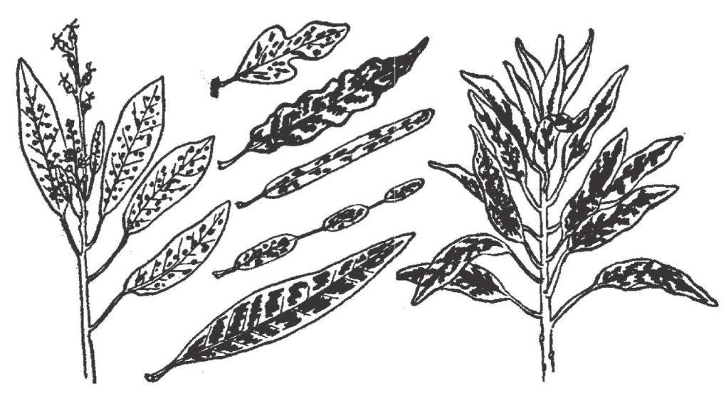

**Figure 13.8:** *Codiaeum variegatum*

| **PMP** |  | *badak | ‘Zingiberaceae spp. with edible rhizomes’ |
| --- | --- | --- | --- |
| **POc** |  | *para(k) | ‘Zingiberaceae spp. with edible rhizomes’ |
| MM | Tolai | *va-var* | ‘*Curcuma longa*’ |
| MM | Tolai | *(ka)va-var* | ‘*Zingiber officinale*’ |
| Fij | Wayan | *va-va* | ‘*Alpinia boia*’ |

## 6. Plants with large colourful leaves

### 6.1. *Codiaeum variegatum*, croton, TP purpur, Bkala lif (Euphorbiaceae)

*Codiaeum variegatum* usually takes the form of a non-woody shrub a metre or more in height, consisting of a clump of large leathery leaves, at their largest 30cm by 9 em. In the wild the leaves are green and the plant may grow into a small tree up to 5 m tall. Under cultivation the leaves vary greatly in shape and colour, and traditionally, *Codiaeum variegatum* was cultivated for its brilliant colours, although it grows in the wild in open locations with access to sunlight (Peekel 1984: 313,Wheatley 1992:89, 91). Kwa’ioloa & Burt (2001: 175) names five cultivars, four of them distinguished by colour (green, yellow, red and dark red).

*Codiaeum variegatum* shrubs were cultivated around the edges of villages for their decorativeness and as boundary markers and markers of taboo sites like graves. They also provided a source ofleaves to decorate men’s bodies during dances (Floyd 1954, Kwa’ioloa & Burt 2001: 175, Wheatley 1992: 91, Hviding 2005: 117, Gardner & Pawley 2006).[^17]:

On New Britain the bark or the leaves were rubbed on the skin to cure skin diseases (Powell 1976). On Waya Island the leaves are used in the treatment of high blood pressure (Gardner & Pawley 2006).

### 6.2. *Cordyline fruticosa* (syn. *Cordyline terminalis*, *Taetsia fruticosa*), cordyline, victory leaf, ti plant, TP tangget, Bnanggaria (Agavaceae)

*Cordyline fruticosa* has a woody stem usually 1-2m high with no branches; the leaves issue from the top of the stem. There is a great variety of leaf shapes from long and narrow to broadly oval and a great variety of leaf colours: green with white: or red stripes, white with green or red stripes, rose-red, rose-red and dark-red stripes, and dark-redl to blackish purple (Peekel 1984: 81-83).

The cordyline has a tuber which is edible and occasionally eaten in Papua New Guinea, although it may have been used more extensively for food in the past. Its young leaf shoots are sometimes cooked and eaten (Barrau 1965, Bourke 1982: 60, French 1986: 335). The Saliba eat the flowers, cooked with leaves of *Gnetum gnemon* (ch.10, §2.3) (Margetts 2005b). The Molima simply add them to the cooking pot (A. Chowning, pers. comm.). *Cordyline fruticosa* is used for plot markers, and tuberous root as an item of clothing, and as a warning to thieves (Bourke 1982).

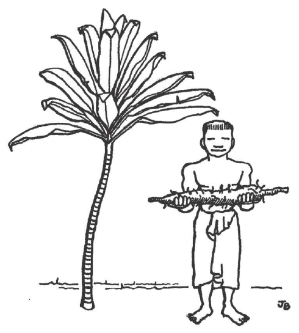

**Figure 13.9:** *Cordyline fruticosa*: plant

Leaves of C.fruticosa are worn by dancers in New Britain (Arentz et al. 1989: 94). Bourke comments on the spiritual significance of C.fruticosa in some Papua New Guinea societies. The Marovo believe that cordyline holds spiritual power, and different cultivars of cordyline are used for different kinds of magic, often exercised by holding the leaf itself (Hviding 2005: 118). It also functions as a charm against magic among the Kwaio and the Kwara’ae, and the latter is the one place where a non-decorative, non-ritual use is mentioned: it is used to wrap lizards for cooking (Kwa’ioloa & Burt 2001: 180). On Waya Island it is usually planted in villages and at taboo sites, and today often at graves. Different varieties were used for different kinds of magic (Gardner & Pawley 2006).

### 6.3. *Dracaena angustifolia* (Liliaceae)

In its mature form *Dracaena angustifolia* is a woody shrub growing to 3-6 m high. It has no bole and splits into many branches at ground level. Each branch splits again recursively, and at the end of each branch, issuing directly from it, is a plume of long narrow leaves. In cultivated varieties these leaves are often brightly striped. *Dracaena angustifolia* receives far fewer mentions in the literature than croton or cordyline: Hviding, for example, does not mention it. This may be because non-botanist observers have confused the species or because *Dracaena angustifolia* has less magical and taboo significance. Kwa’ioloa & Burt (2001: 181) say that it is used for living fences. However, the Arosi dictionary describes it as a very sacred plant which is planted on burial grounds and on gardens to protect crops, is used in divination, and is waved at the annual harvest ceremony (Fox 1978). Sa’a speakers use the leaves in incantations, in bonito ceremonials and in malevolent magic (Ivens 1929). On Ulawa the priest uses a *Dracaena* branch bound with a climbing fern to draw out the yam beetles when a garden is dedicated for planting. Such a branch is then planted at the entrance stile to keep out disease (Ivens 1927:360, 362).

### 6.4. Reconstructions

*Cordyline* and *Dracaena* varieties are both used as decorative plants and for making leaf skirts, and many Oceanic languages treat them as a single taxon. In E Kara (MM), for example, si denotes *Cordyline fruticosa*, and the binomial si tavul is *Dracaena angustifolia*. In Kwara’ae *Cordyline fruticosa* is dili and *Dracaena angustifolia* is mala-dili ‘resembling cordyline’ (see ch.2, §7 .1.4 ). Each of the cognate sets below spans plants of both genera, and it is probable that many more of the glosses should refer to both *Cordyline* and *Dracaena*: the full span of the denotation was missed when the data were recorded.

Chowning (1963, 2001: 81) suggests that the ‘Prato-Melanesian’ terms *babaka,[^18]: *dili (my POc *jiRi ‘*Cordyline* sp., *Dracaena* sp.’) and *male (my PWOc *mʷa(r,R)e ‘*Codiaeum variegatum*; *Cordyline fruticosa*’) were each used collectively for three species. Her first two species are *Codiaeum variegatum* and *Cordyline fruticosa*. Her third, however, is not *Dracaena angustifolia*, but *Cycas rumphii*. She writes that all three are ‘used primarily for decorative and magico-religious purposes’ (Chowning 1963).[^19]:

It is quite possible that PWOc *mʷa(r,R)e indeed denoted a taxon including Codiaeum variegatum and *Cordyline fruticosa*, and perhaps other decorative plants (note Nakanai *mamale* ‘*Cananga odorata*’), but I have found no evidence of a term that denoted plants of all three species. Possibly Chowning considered some of the items collected together under PEOc *mʷa(q)ele ‘cycad’ (ch.9, §5.2) to belong to the same cognate set as the items under PWOc *mʷa(r,R)e below. Despite the formal similarity between the two reconstructions, however, the two cannot be reconciled: reflexes of the former agree in reflecting *-l-, the latter in reflecting *-(r,R)-. The two sets can be united only by positing irregular sound change or borrowing.[^20]:

Three other etyma are reconstructed below: POc *jiRi, *kaRi(q)a and *jajal. POc *jiRi indeed introduces a third species into the discussion, but it is *Dracaena angustifolia*, not *Cycas rumphii*. The distribution of the reflexes of POc *kaRi(q)a ‘taxon of decorative plants’ leaves us unable to determine which of the three species it denoted. POc *jajal probably denoted a particular variety of *Codiaeum variegatum*.

| **PWOc** |  | *mʷa(r,R)e | ‘taxon including *Codiaeum variegatum* and *Cordyline fruticosa*’ (Chowning 1963: *male; Ross 1996d) |
| --- | --- | --- | --- |
| NNG | Kove | *mohe* | ‘*Cordyline* sp.’ (Chowning 1996: 17) |
| NNG | Yabem | *(ka)maʔ* | ‘*Cordyline* sp.’ |
| NNG | Takia | *mra-mor* | ‘*Cordyline fruticosa*’ |
| NNG | Kairiru | *(moel) morie(p)* | ‘thin-leaved, green variety of *Codiaeum variegatum*’ |
| PT | Roro | *mare* | ‘plant with yellow leaves’ |
| MM | Vitu | *mare* | ‘*Cordyline* sp.’ |
| MM | Bulu | *mara* | ‘*Cordyline* sp.’ |
| MM | Nakanai | *male-male* | ‘*Cordyline* sp.’ (Chowning 1996: 17) |
| MM | Nakanai | *ma-male* | ‘*Cananga odorata* (like *Cordyline* used for personal adornment)’ (Floyd 1954) |
| MM | East Kara | *ma-mara* | ‘*Codiaeum variegatum*’ |
| MM | Patpatar | *mora-mora* | ‘*Codiaeum variegatum*’ |
| MM | Kandas | *muro* | ‘*Codiaeum variegatum*’ |
| MM | Roviana | *mar-mar* | ‘*Codiaeum variegatum*’ |

cf. also:

| SV | Anejom̃ | *na-mraθ* | ‘*Codiaeum variegatum*’ |
| --- | --- | --- | --- |
| Fij | Wayan | *ŋʷali* | ‘croton, *Codiaeum variegatum*’ |

| **PMP** |  | *siRi | ‘*Cordyline* sp., *Dracaena* sp.’ (Blust 1989) |
| --- | --- | --- | --- |
| **POc** |  | *jiRi | ‘taxon consisting of *Cordyline fruticosa* and *Dracaena angustifolia*’ (Milke 1968: *diRi; Ross 1988) |
| Adm | Mussau | *sii* | ‘banyan, *Ficus* sp.’ |
| Adm | Kurti | *siy* | ‘*Dracaena* sp.’ |
| Adm | Wuvulu | *ti* | ‘*Dracaena* sp.’ |
| Adm | Aua | *ti* | ‘*Dracaena* sp.’ |
| Adm | Ere | *siy* | ‘*Dracaena* sp.’ |
| NNG | Malasanga | *sir* | ‘grass skirt’ |
| NNG | Mindiri | *(da)dir* | ‘grass skirt’ |
| NNG | Mapos Buang | *sĩ* | ‘tree sp., Euphorbeaceae’ |
| NNG | Wampur | *riciʔ* | ‘cordyline’ |
| NNG | Adzera | *ji-ji* | ‘cordyline’ |
| NNG | Kairiru | *jir* | ‘small pandanus sp.’ |
| PT | Wedau | *diri* | ‘*Dracaena* sp.’ |
| PT | Tawala | *diri* | ‘*Dracaena* sp.’ |
| PT | Molima | *dili* | ‘red cordyline’ |
| MM | Tiang | *si* | ‘cordyline’ |
| MM | East Kara | *si* | ‘*Cordyline fruticosa*’ |
| MM | East Kara | *si(-tavul)* | ‘*Dracaena angustifolia*’ |
| MM | Nalik | *sir* | ‘cordyline’ |
| MM | Tabar | *cir* | ‘cordyline’ |
| MM | Lihir | *cir* | ‘*Cordyline terminalis*/*Cordyline fruticosa*’ |
| MM | Notsi | *cil* | ‘cordyline’ |
| MM | Konomala | *si* | ‘cordyline’ |
| MM | Patpatar | *suri(ah)* | ‘*Dracaena angustifolia*’ |
| MM | Tolai | *ir* | ‘leaf of the croton’ (ACD) |
| MM | Ramoaaina | *ir-ira* | ‘croton leaf, *Dracaena*’ |
| MM | Petats | *rin* | ‘cordyline’ |
| MM | Taiof | *rir* | ‘cordyline’ |
| MM | Varisi | *zili(para)* | ‘*Cordyline fruticosa*’ (W. McClatchey, pers. comm.) |
| MM | Marovo | *ji(polo)* | ‘*Cordyline fruticosa*’ |
| MM | Roviana | *zi(polo)* | ‘shrub, *Dracaena* sp.’ |
| SES | Gela | *dili* | ‘*Dracaena*’ |
| SES | Lau | *dili* | ‘*Dracaena* with thin green leaves’ |
| SES | Kwara’ae | *dili* | ‘*Cordyline fruticosa*’ |
| SES | Kwaio | *dili* | ‘*Cordyline fruticosa*’ |
| SES | ’Are’are | *siri* | ‘herb with red stem and leaves, used for magical purposes’ |
| SES | Sa’a | *dili* | ‘Draecena’ |
| SES | Arosi | *diri* | ‘Draecena’ |
| NCal | Nyelâyu | *di* | ‘*Cordyline fruticosa*’ |
| Mic | Chuukese | *tĩ-n* | ‘*Cordyline fruticosa*’ |
| **PCP** |  | *jĩ | ‘taxon consisting of *Cordyline fruticosa* and *Dracaena angustifolia*’ |
| Fij | Rotuman | *jĩ* | ‘plant with ornamental leaves and a sweet root: *Cordyline fruticosa*’ |
| Pn | Tongan | *sĩ* | ‘*Cordyline fruticosa*’ |
| Pn | East Futunan | *tĩ* | ‘*Cordyline fruticosa*’ |
| Pn | Rennellese | *tĩ* | ‘*Cordyline fruticosa*’ |
| Pn | West Uvea | *tĩ* | ‘Draecena’ |
| Pn | Emae | *tĩ* | ‘*Cordyline* sp.’ |
| Pn | Samoan | *tĩ* | ‘*Cordyline fruticosa*’ |
| Pn | Tikopia | *tĩ* | ‘*Cordyline* sp.’ |
| Pn | Tuamotuan | *tĩ* | ‘*Cordyline fruticosa*’ |
| Pn | Hawaiian | *kĩ* | ‘*Cordyline fruticosa*’ |
| Pn | Marquesan | *tĩ* | ‘*Cordyline* sp.’ |
| Pn | Tahitian | *tĩ* | ‘*Cordyline fruticosa*’ |
| Pn | Māori | *tĩ* | ‘*Cordyline* sp.’ |

Medial parenthesised *-q- is reconstructed in POc *kaRi(q)a on the assumption that Vitu *kariɣa* ‘rattan’ is cognate, but the difference in denotation calls this into doubt.

| **POc** |  | *kaRi(q)a | ‘taxon of decorative plants’ (Geraghty 1990: PEOc *gaRi(a)) |
| --- | --- | --- | --- |
| NNG | Tami | *kali-kali* | ‘*Codiaeum variegatum*’ (Dempwolff 1902) |
| SES | Kwara’ae | *ka-kali* | ‘*Hornstedtia lycostoma*’ (Henderson and Hancock 1988) |
| NCV | Mota | *karia* | ‘*Dracaena* sp.’ |
| NCV | Ambae | *karie* | ‘*Cordyline* sp.’ |
| NCV | Raga | *ɣaria* | ‘generic for *Cordyline* spp.’ |
| NCV | Atchin | *kari* | ‘*Dracaena* sp.’ |
| NCV | Uripiv | *gari* | ‘*Cordyline* sp.’ |
| NCV | Naman | *na-ɣari* | ‘*Cordyline* sp.’ |
| NCV | Neve’ei | *na-ʔari* | ‘*Cordyline* sp.’ |
| NCV | Larëvat | *na-ɣri* | ‘*Cordyline* sp.’ |
| NCV | Port Sandwich | *xari* | ‘crotons’ |
| NCV | Lewo | *(puru)kalie* | ‘*Cordyline* sp.’ |
| NCV | Namakir | *kari* | ‘*Cordyline* sp.’ |
| NCV | Nguna | *na-karie* | ‘palm-lily plant, *Dracaena* sp.’ |
| SV | Sye | *(tana)ŋklai* | ‘*Cordyline* sp.’ |
| Fij | Bauan | *gai* | ‘*Cordyline* sp.’ |

cf. also:

| MM | Vitu | *kariɣa* | ‘rattan’ |
| --- | --- | --- | --- |

| **POc** |  | *jajal | ‘croton, *Codiaeum variegatum*’ |
| --- | --- | --- | --- |
| NNG | Yabem | *(ka)dada* | ‘a grassland shrub, the sap of which is used to blacken teeth’ (probably *Rhus taitensis*-MDR) |
| MM | Nehan | *dedel(am)* | ‘*Codiaeum variegatum*, yellow and green variety’ |
| MM | Varisi | *zazala (piru)* | ‘Codiaeum sp.’ (W. McClatchey, pers. comm.) |
| MM | Babatana | *jajala* | ‘*Codiaeum variegatum*’ (W. McClatchey, pers. comm.) |
| MM | Nduke | *zazala* | ‘*Codiaeum variegatum*’ |
| MM | Roviana | *zazala* | ‘*Codiaeum variegatum*’ |
| MM | Marovo | *jajala* | ‘*Codiaeum variegatum*’ |
| NCV | Mwotlap | *na-sas* | ‘*Codiaeum variegatum*’ |
| NCV | Mota | *sasa* | ‘*Codiaeum variegatum*’ |
| NCV | Ambae | *sasa* | ‘*Codiaeum variegatum*’ |
| NCV | Lonwolwol | *ha* | ‘*Codiaeum variegatum*’ |
| NCV | Raga | *hahali* | ‘*Codiaeum variegatum*’ |
| NCV | Apma | *sasli* | ‘*Codiaeum variegatum*’ |
| NCV | Uripiv | *na-jej* | ‘*Codiaeum variegatum*’ |
| NCV | Rerep | *ne-jaj* | ‘*Codiaeum variegatum*’ |
| NCV | Neve’ei | *ne-nsah* | ‘*Codiaeum variegatum*’ |
| NCV | Tape | *cec* | ‘*Codiaeum variegatum*’ |
| NCV | Avava | *a-sah* | ‘*Codiaeum variegatum*’ |
| NCV | Lonwolwol | *ha* | ‘*Codiaeum variegatum*’ |
| Fij | Bauan | *ðaða* | ‘*Codiaeum variegatum*’ (Geraghty 2004: 79) |
| Fij | Rotuman | *sasa* | ‘*Codiaeum variegatum*’ (Geraghty 2004: 79) |

### 6.5. *Heliconia indica*, heliconia, Blif laplap (Heliconiaceae)

Two species of *Heliconia* grow in NW Island Melanesia, *Heliconia indica* in eastern mainland New Guinea and the Bismarcks and *Heliconia solomonensis* in Bougainville and the Solomons (R. Gardner, pers. comm.). The two appear to be very· similar (Figure 13.10, left).[^21]: Numerous short stems formed from leaf sheaths rise from an underground rhizome to a height of 5 or 6 m. The leaves resemble banana leaves, and under cultivation assume various colours and patterns: yellow, yellow-and-green striped, bright red or dark red. In the wild heliconias grow in damp shady environments in primary and secondary forest.

The leaves are used for covering and sealing the stone oven because of their thick, waxy cuticle and very large leaf surfaces. Thanks to their size, fewer are needed, reducing the labour of cutting and carrying (Henderson & Hancock 1988:239, Kwa’ioloa & Burt 2001: 196, Hviding 2005: 120).

| **POc** |  | *paqo | ‘*Heliconia* sp’ |
| --- | --- | --- | --- |
| MM | Nduke | *vaɣo* | ‘a large: perennial herb with banana-like leaves, *Heliconia solomonensis*’ |
| MM | Marovo | *vaɣo* | ‘tree sp. with large banana-like leaves, *Heliconia* sp.’ |
| SES | Gela | *vao-vao* | ‘shrub with large leaves; wild banana’ |
| SES | Santa Ana | *fao* | ‘*Heliconia solomonensis*’ |
| NCV | Mwotlap | *(no-yo)va* | ‘*Heliconia indica*’ (*yo-* ’leaf) |
| NCV | Mota | *vao* | ‘a heliconium’ |
| Fij | Wayan | *vā-vā* | ‘*Heliconia* sp.’ |
| Fij | Bauan | *va-vao(a)* | ‘a plant, Bleekeria elliptica’ |

| **PEOc** |  | *rako | ‘*Heliconia* sp., usually *Heliconia indica*’ (Lynch 2004a: PSOc *rau) |
| --- | --- | --- | --- |
| SES | Kwara’ae | *rako* | ‘*Heliconia indica*’ |
| NCV | South Efate | *n-rau* | ‘*Heliconia* sp.’ |
| SV | Sye | *n-rau* | ‘*Heliconia* sp.’ |
| SV | Ura | *lau* | ‘*Heliconia* sp. (generic)’ |

### 6.6. *Crinum asiaticum*, spider lily (Amatyllidaceae)

*Crinum asiaticum* is a large lily with long erect leaves that are arranged in a spiral rosette to form impressive clumps up to 1.5 m in height and 2 m wide (Figure 13.10, right). The leaves may be a metre long and 10cm wide. They emerge from huge bulbs that may weigh as much as 9 kg. Its white flowers, with thick succulent stems, are shaped like tubes that flair open into a crown of narrow petals.[^22]: Hviding (2005: 103) distinguishes between *Crinum asiaticum*, which is cultivated, and *Crinum pedunculatum*, which grows wild in sandy areas near beaches and in other damp locations. Kwa’ioloa & Burt (2001: 216) distinguish between a green-leaved wild variety of *Crinum asiaticum* and a yellow-leafed variety cultivated for decoration in villages.

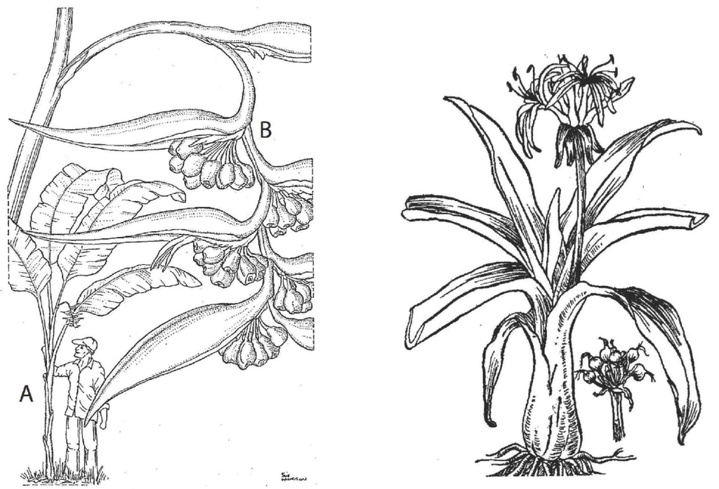

**Figure 13.10:** Left: *Heliconia* solomonensis: **A**, plant; **B**, mature inflorescence, open and showing fruit. Right: *Crinum asiaticum*, spider lily.

At Tinputz (Bougainville) the pounded roots of this plant were mixed with red iron oxide and the mixture was rubbed onto coconut palm trunks to ensure that they bore well (Blackwood 1935: 311). The Nakanai of New Britain and the Marovo use the light-coloured leaf bases as trolling lures to catch large fish, in Marovo barracuda and Spanish mackerel (Hviding 2005: 103, Floyd 1954). The Nakanai also use the leaves for making women’s leaf skirts. In Marovo the leaves are used to treat bruises and fractures.

The forms listed below are clearly cognate, but it is not clear whether or how many of the parenthesised segments of the Kairiru and Kilivila forms reflect part of the protoform: hence the question mark against *mʷalak.

| **POc** |  | *mʷalak | ‘spider lily, *Crinum asiaticum*’ |
| --- | --- | --- | --- |
| NNG | Kairiru | *mlak(ap)* | ‘*Crinum asiaticum*’ |
| PT | Kilivila | *mola(bau)* | ‘a lily, *Crinum asiaticum*’ |
| **PSOc** |  | *mʷalak | ‘spider lily, *Crinum asiaticum*’ (Lynch 2004a) |
| NCV | Mwotlap | *mʷ[a]lak* | ‘spider lily, *Crinum asiaticum*’ |
| SV | Anejom̃ | *no-(hos)meleɣ* | ‘Crinum sp.’ |

## 7. Cucurbits

The four plants discussed below, namely the bottle gourd (*Lagenaria siceraria*), the wax gourd (*Benincasa hispida*), the pumpkin (*Cucurbita moschata*) and the cucumber (*Cucumis sativus*) have in common not only that they all grow on vines but, more relevant here, that the dates and directions of their introductions into Oceania have been objects of controversy. The linguistic evidence supports the controversial claim that the pumpkin, *Cucurbita moschata*, was absent from the world of POc speakers but arrived soon after the break-up of POc.

### 7.1. *Lagenaria siceraria* (syn. *Lagenaria vulgaris*, *Lagenaria leucantha*, *Cucurbita siceraria*, *Cucurbita lagenaria*), bottle gourd, TP *kambang* (Cucurbitaceae)

The bottle gourd, *Lagenaria siceraria*, is grown throughout much of the Pacific, mainly for its value as a container and occasionally for its food value (French 1986: 107). The plant originated in Africa, but had spread across much of the world in pre-Columbian times. Barrau (1962: 189) regards it as an ancient plant in Melanesia, but no POc form can be reconstructed, as noted by Ross (1996d).

Clark (1996) reconstructs PNCV *tavaya (Raga *tavai*, Mota *wo-tavae*), which, together with Bauan *tavaya* ‘bottle’, implies PEOc *tapaya. But no cognates of the latter nor alternative cognate sets have been found in Western Oceanic or Admiralties languages, implying that the bottle gourd was not known to POc speakers. Surveying recent findings, Green (2000) suggests quite strongly that this was the case. The gourd may well have reached Oceania from two directions, arriving in Melanesia from the Indo-Malaysian region and much later in eastern Polynesia from South America. There is good evidence that the Polynesians did not carry the gourd with them into eastern Polynesia (Whistler 1990, 1991). It is thus possible - and on the linguistic evidence likely - that the bottle gourd first reached the Bismarck Archipelago after the break-up of POc.

### 7.2. *Benincasa hispida*, wax gourd, white gourd, winter melon (Cucurbitaceae)

Golson (2002) also provides a survey of archaeological evidence which shows that allegedly pre-Oceanic dates for the bottle gourd in Oceania are the result of misidentification of remains of the wax gourd, *Benincasa hispida*. Whistler (1990) similarly shows that reports of the bottle gourd in Polynesia reflect incorreclt identifications of the wax gourd. The latter is a native of SE Asia and archaeological evidence indicates that it was present at least on mainland New Guinea when the Austronesian speaking ancestors of POc speakers arrived there. There are terms for it in non-Oceanic languages: terms from Philippine languages listed by Madulid (2001b: 42) together with Malay kundur point to a possible PMP *kundur, but this may be an outcome of borrowings across island SE Asia (Wolff 1994). Verheijen (1990: 195) cites terms that point to a possible PCMP *kelas. As Golson points out, the botanical literature indicates that *Benincasa hispida* is at least occasionally present at locations on the mainland and in the Bismarcks where Oceanic languages are spoken today. In support of this he cites Peekel (1984: 547-548) and Borrell (1989: 66). French (1986: 108) also indicates that *Benincasa hispida* is grown in Papua New Guinea, but does not specify locations.

Whistler provides names for *Benincasa hispida*, listed below, which allow us to reconstruct Proto Central Pacific *vaŋ(o,u). I have accepted his arguments for glossing the Fijian terms as *Benincasa hispida*: his sources (H. B. R. Parham 1943, Capell 1941) gloss them as species of Lagenaria. Despite the obvious presence of *Benincasa hispida* further west I have been unable to reconstruct an earlier term for it, but not for the usual reasons. Usually, a term is not reconstructable because there are no cognates in the data or because cognates are insufficiently widespread. In the case of *Benincasa hispida*, however, there are no data from outside Fiji and Polynesia except Peekel’s Patpatar *hulhul paraho*. This can only indicate that, even if *Benincasa hispida* was present in early Oceanic times, its presence and significance in the agricultural suite of Oceanic-speaking societies has faded almost to zero.[^23]:

| **PCP** |  | *vaŋ(o,u) | ‘wax gourd, *Benincasa hispida*’ |
| --- | --- | --- | --- |
| Fij | Lau (Eastern Fijian) | *vaŋo* | ‘*Benincasa hispida*’ |
| Fij | Bauan | *vaŋo* | ‘*Benincasa hispida*’ |
| Pn | Tongan | *faŋu* | ‘*Benincasa hispida*’ |
| Pn | Niuean | *faŋu* | ‘bottle’ |
| Pn | Samoan | *faŋu* | ‘*Benincasa hispida*’ |
| Pn | East Uvean | *faŋu* | ‘*Benincasa hispida*’ |
| Pn | East Futunan | *faŋu* | ‘*Benincasa hispida*’ |

### 7.3. *Cucurbita moschata*, pumpkin, TP pamken (Cucurbitaceae)

Barrau (1962: 190) declares that the pumpkin[^24]: is a European introduction to Melanesia, and the linguistic data largely support his assertion. A number of terms for it are borrowings from English (MM: E Kara baniyin, Tinputz banken, NCV: Paamese vamuken, Lewo pamken) or from elsewhere (PT: Motu mausini, Roro mauteni, apparently from Samoan mau- tini ‘gourd’).

The set of seeming cognates below provides evidence, on the other hand, of an early Oceanic etymon, *waluq or *[w]aruq, thatmusthave denoted *Cucurbita moschata* or a similar plant. I write ‘seeming’ because, however one reconstructs the term, there are irregular phonological developments due to borrowing. Dempwolff (1938) reconstructed *baluq ‘bottle gourd, *Lagenaria siceraria*’. However, the Oceanic forms below, together with Sundanese, Old Javanese, Balinese *waluh*, Buru *walu* ‘bottle gourd’, point to PMP *waluq ‘bottle gourd’. Whether PMP actually had such a form or whether this is a series of borrowings postdating the break-up of PMP and perhaps even of POc (cf §7.1) is not relevant here. What is relevant is that a form related to these entered early Oceanic, but was applied to the pumpkin, *Cucurbita moschata*, or a related species.

The strong likelihood, then, is that the term was borrowed from community to community sometime very soon after the break-up of POc. That is, *Cucurbita moschata* or a similar plant must have found its way into NW Melanesia not much less that 3000 years ago. The genus Cucurbita is indigenous to the tropical zone of the Americas, where domestication is known to have occurred by 4000 years ago (Sauer 1993).

This finding is not at odds with the historical fact that the modern pumpkin was introduced to NW Melanesia by Europeans after 1870. It simply indicates that a variety of *Cucurbita moschata* or a similar plant was already present, and had been present for a long time, albeit perhaps as a very minor crop in a few areas.

| **Early Oceanic** |  | *waluq, *[w]aruq | ‘pumpkin, *Cucurbita moschata* ?’ |
| --- | --- | --- | --- |
| NNG | Sio | *waru* | ‘pumpkin’ |
| NNG | Kela | *waru-waru* | ‘pumpkin’ |
| NNG | Hote | *lu-alu* | ‘pumpkin’ |
| NNG | Mapos Buang | *ruχ-arūχ* | ‘pumpkin’ (*-r-* for *†-l-*) |
| NNG | Patep | *luʔ-əlu* | ‘pumpkin’ |
| NNG | Dami | *olu* | ‘pumpkin’ |
| NNG | Takia | *walu* | ‘pumpkin’ |
| PT | Gapapaiwa | *bonu-bonu* | ‘pumpkin’ |
| PT | Misima | *bonu-bonu* | ‘pumpkin’ |
| **PSV** |  | *na-r(o,u)r(o,u)(q) | ‘pumpkin, gourd’ |
| SV | Lenakel | *(noua)ne-lulu* | ‘pumpkin’ |
| SV | Anejom̃ | *ne-rero* | ‘gourd’ |

### 7.4. *Cucumis sativus*, cucumber (Cucurbitaceae)

Because of the varieties that have been introduced since 1870, it is sometimes assumed that the cucumber is a crop introduced by Europeans. However, Bourke & Allen (forthcoming) write that it was probably introduced via SE Asia thousands of years ago. The cognate set supporting the reconstruction of POc *[ka]tim(o,u)n ‘cucumber, *Cucumis sativus*’ below con- firms that the cucumber was part of the world of POc speakers, even though it is not indigenous to the Pacific. The genus Cucumis has its origins in Africa, and the cucumber is one of the few African species known to have been domesticated outside Africa. Until recently it was thought that it was part of a suite of plants that were domesticated in the Fertile Crescent of SW Asia or in India, but recent work in molecular biology has cast doubt on this, placing the cucumber instead in an Asian-Australian clade of the genus Cucumis (Renner et al. 2007). There is thus no biogeographic challenge to the proposal that the cucumber was known to both PMP and POc speakers.

Blust (ACD) produces strong evidence to suggest that the denotatum of POc *[ka]tim(o,u)n was the cucumber, but the reflexes below suggest that it may also have been used of other species of Cucumis.

Shown in parentheses below are irregular phonological developments, implying that al- though the term was inherited into POc, it was sometimes borrowed from one language into another.

| **PMP** |  | *[ka]timun | ‘cucurbit (generic); cucumber, *Cucumis sativus*’ (Dempwolff 1938: *timun) |
| --- | --- | --- | --- |
| **POc** |  | *[ka]tim(o,u)n | ‘Cucumis spp. (generic?); cucumber, *Cucumis sativus*’ (ACD) |
| NNG | Sengseng | *tamun* | ‘*Cucumis sativus*’ (A. Chowning, pers. comm.) |
| NNG | Sengseng | *katim* | ‘small cultivated cucurbit with dark green skin and sweet orange flesh’ (A. Chowning, pers. comm.; probably borrowed) |
| NNG | Gitua | *karimon* | ‘cucumber’ (ACD) |
| NNG | Mapos Buang | *qatimŋ* | ‘cucumber, *Cucumis sativus*’ |
| NNG | Patep | *kətima* | ‘cucumber, *Cucumis sativus*’ (*-a-* for †*-(o,u)-*) |
| NNG | Numbami | *katimana* | ‘cucumber’ (*-a-* for †*-(o,u)-*) |
| PT | Motu | *asemo* | ‘small wild cucumber, Cucumis sp.’ (ACD) |
| MM | Sursurunga | *katmur* | ‘vegetable like pumpkin or cucumber’ (*-r* for †*-n*) |
| MM | Tolai | *katimur* | ‘Pacific melon, Cucumis melo’ (*-r* for †*-n*) |
| MM | Teop | *asimuru* | ‘a vegetable like a cucumber’ (*-r* for †*-n*) |
| MM | Tinputz | *asimū* | ‘cucumber’ |
| Fij | Bauan | *timo* | ‘a plant, Cucumis acidus’ |
| Pn | East Futunan | *timo* | ‘melon’ |

## Notes

[^1]: Lime is made by crushing coral or shells, burning them to produce calcium oxide, then slaking this to produce calcium hydroxide (R.M. Bourke, pers. comm.).
[^2]: Anthropological and linguistic literature on the origins of kava usually retains the species name wichmannii, but the accepted botanical name is subbullatum (R. Gardiner, pers. comm.).
[^3]: This summary by no means does justice to Lynch’s (2002) article, to which the reader is referred for further detail.
[^4]: The term ‘kava’ in the glosses here probably means both the plant and the drink: sources use it without further specification.
[^5]: *Hedychium coronarium* has apparently arrived since European contact.
[^6]: Kwa’ioloa & Burt (2001: 202) label it *Nastus productus*, but this does not coincide with others’ descriptions of the latter.
[^7]: I am grateful to Françoise Ozanne-Rivierre and John Lynch for drawing my attention to this.
[^8]: POc *R is reflected as Mussau, Nakanai and Petats *l*.
[^9]: In Blust’s orthography *kaundu.
[^10]: This reconstruction is maintained in the ACD in the notes to the entry for *qauR.
[^11]: Blust (1970) reconstructs *maru on the basis of Buru (CMP) maru and Oceanic reflexes, but the second syllables of the two forms do not correspond (as Blust notes).
[^12]: Cf. ch.9, §4, where a similar but not identical situation is described with regard to breadfruit.
[^13]: Raga *ɣuresi* reflects the irregular retention of the POc final consonant and addition of *-i* discussed in §3.6.
[^14]: No reconstruction for Alpinia is made in this volume.
[^15]: According to Geraghty (2004: 67) Kiribati *reŋa* is borrowed from a Polynesian language.
[^16]: Unfortunately, Kwa’ioloa & Burt (2001: 193-194) describe wild ginger and turmeric together, and it is impossible to work out which uses are attributed to which plant.
[^17]: According to Wheatley, the other leaves used as dance decoration were from *Euodia hortensis* (ch.7, §5 .6) and from *Polyscias* species (ch.lO, §2.4).
[^18]: I do not have access to the data on the basis of which *babaka was reconstructed.
[^19]: In her 2001 discussion of PWOc *mʷa(r,R)e as presented by Ross (1996d), she corrects the gloss of Nakanai *male* from ‘Codiaeum’ to ‘*Cordyline*’ and adds the Kove etymon.
[^20]: I initially thought that Anejom *na-mraθ* ‘Croton insularis’ was cognate with the items under POc *mʷa(r,R)e. However, members of the genus Croton are substantial trees which have little in common with *Codiaeum variegatum*, popularly called ‘croton’ (although both belong to the family Euphorbiaceae).
[^21]: An editor’s footnote indicates that Peekel (1984: 98, 100) incorrectly identified *Heliconia indica* as *H. bihai*, an American species.
[^22]: http://www.floridata.com/, accessed October 2007
[^23]: Barrau (1962: 189) lists *Benincasa hispida* as a recent introduction to Oceania: he is apparently wrong, although there may have been recent reintroductions.
[^24]: Barrau refers to the pumpkin as *Cucurbita pepo*. In Papua New Guinea, at least, the common pumpkin is *Cucurbita moschata*, not *C. pepo* (R. Michael Bourke, pers. comm., and French 1986: 102-103). Both are evidently recent introductions, so this possible confusion makes no difference to the argument of this paragraph.
[^25]: Hote, Patep and Lenakel also neutralise *-l- and *-r-, but I have ignored this here for the sake of simplicity of presentation.